# Assignment_3_sanje2

Sai Anjesh

2024-03-11

```r
## Essential modules to import
library(dplyr)
library(C50)
```

# Problem1—Predicting Income using Logistic Regression and Decision Trees

### For this problem, you will be using the Adult dataset from here (https://archive.ics.uci.edu/ml/datasets/adult ) and the goal is to use a logistic regression and a decision tree model to predict the binary variable income (>50K or <=50K) based on the other attributes in the dataset. Read the attribute information from here then click on the datafolder and download “adult.data”.

##### 1. (0.5 pt) Load adult.data into a dataframe in R. Note that adult.data does not have column names in the first line so you need to set header=FALSE when you read the data then manually set the column names. Inspect the dataset using “str” and “summary” functions. What is the type of each variable in the dataset numeric/continuous or categorical/discrete? For each categorical variable explain whether it is nominal or ordinal.

```r
# Input data paths
adult_data_path <- "D:/UIS/Studies/Semester4/CSC532/Assignments/Assignment3/regression_project/input_datasets/adult/adult.data"
```

```r
# Reading data
adult_data <- read.csv(file = adult_data_path,
                       header = FALSE,
                       na.strings = " ?")

# Ccolumn names
adult_data_header <- c(
  "age",
  "workclass",
  "fnlwgt",
  "education",
  "education_num",
  "marital_status",
  "occupation",
  "relationship",
  "race",
  "sex",
  "capital_gain",
  "capital_loss",
  "hours_per_week",
  "native_country",
  "income"
)

# Updating the header
colnames(adult_data) <- adult_data_header
```

Let us check the structure and summary of the dataset.

```r
str(adult_data)
```

```
## 'data.frame':    32561 obs. of  15 variables:
##  $ age           : int  39 50 38 53 28 37 49 52 31 42 ...
##  $ workclass     : chr  " State-gov" " Self-emp-not-inc" " Private" " Private" ...
##  $ fnlwgt        : int  77516 83311 215646 234721 338409 284582 160187 209642 45781 159449 ...
##  $ education     : chr  " Bachelors" " Bachelors" " HS-grad" " 11th" ...
##  $ education_num : int  13 13 9 7 13 14 5 9 14 13 ...
##  $ marital_status: chr  " Never-married" " Married-civ-spouse" " Divorced" " Married-civ-spouse" ...
##  $ occupation    : chr  " Adm-clerical" " Exec-managerial" " Handlers-cleaners" " Handlers-cleaners" ...
##  $ relationship  : chr  " Not-in-family" " Husband" " Not-in-family" " Husband" ...
##  $ race          : chr  " White" " White" " White" " Black" ...
##  $ sex           : chr  " Male" " Male" " Male" " Male" ...
##  $ capital_gain  : int  2174 0 0 0 0 0 0 0 14084 5178 ...
##  $ capital_loss  : int  0 0 0 0 0 0 0 0 0 0 ...
##  $ hours_per_week: int  40 13 40 40 40 40 16 45 50 40 ...
##  $ native_country: chr  " United-States" " United-States" " United-States" " United-States" ...
##  $ income        : chr  " <=50K" " <=50K" " <=50K" " <=50K" ...
```

```r
summary(adult_data)
```

```
##       age         workclass             fnlwgt         education
##  Min.   :17.00   Length:32561       Min.   :  12285   Length:32561
##  1st Qu.:28.00   Class :character   1st Qu.: 117827   Class :character
##  Median :37.00   Mode  :character   Median : 178356   Mode  :character
##  Mean   :38.58                      Mean   : 189778
##  3rd Qu.:48.00                      3rd Qu.: 237051
##  Max.   :90.00                      Max.   :1484705
##  education_num   marital_status      occupation        relationship
##  Min.   : 1.00   Length:32561       Length:32561       Length:32561
##  1st Qu.: 9.00   Class :character   Class :character   Class :character
##  Median :10.00   Mode  :character   Mode  :character   Mode  :character
##  Mean   :10.08
##  3rd Qu.:12.00
##  Max.   :16.00
##      race               sex             capital_gain    capital_loss
##  Length:32561       Length:32561       Min.   :    0   Min.   :   0.0
##  Class :character   Class :character   1st Qu.:    0   1st Qu.:   0.0
##  Mode  :character   Mode  :character   Median :    0   Median :   0.0
##                                        Mean   : 1078   Mean   :  87.3
##                                        3rd Qu.:    0   3rd Qu.:   0.0
##                                        Max.   :99999   Max.   :4356.0
##  hours_per_week  native_country        income
##  Min.   : 1.00   Length:32561       Length:32561
##  1st Qu.:40.00   Class :character   Class :character
##  Median :40.00   Mode  :character   Mode  :character
##  Mean   :40.44
##  3rd Qu.:45.00
##  Max.   :99.00
```

age : Numerical variable - Discrete - Integer - this variable tells discrete. workclass : Caetgorical variable - Nominal fnlwgt : Numerical variable (although it has integers, it can be considered as continous) education : Categorical variable - Nominal variable - But can be considered ordnial. But for this problem I have considered it to be the nominal variable. education_num : Numerical - integer variable - discrete in nature. marital_status: Categoriacl variable - nominal variable occupation : Categorical variable - nominal varaiable relationship : Categoriacl variable - nominal variable race : Categoriacl variable - nominal variable sex : Categoriacl variable - nominal variable capital_gain : Numerical variable - discrete in nature capital_loss : numerical variable and discrete integree variable hours_per_week: numerical variable and discrete integree variable native_country: Categorical variable - nominal varaiable income : Categorical variable - nominal varaiable

##### 2. (0.5 pt) There are some missing values in this dataset represented as “ ?” (Note: there is a space before?). Make sure that all “ ?” are converted to NAs. You can do so by setting “na.strings” parameters in “read.csv” to “ ?”.

Yes answer for this question is updated in the previous answer.

##### 3. (1pt) Set the random seed, and split the data to train/test. Use 80% of samples for training and the remaining 20% for testing. You can use “sample” (similar to what we did in slide 37 of week 6 lecture but you need to adjust 1000 and 900 to the number of observations in your dataset and the size of the sample) or alternatively, you can use “createDataPartition” method from caret package.

```r
# Setting the seed to 123
# to repeat the same random sample from our dataset
set.seed(123)

# Let us use the sample technique from lecture notes pdf
num_of_recs <- nrow(adult_data)
train_split_perc <- 0.8
train_split_size <- round(x = train_split_perc * num_of_recs, digits = 0)
train_sample_index <- sample(x = num_of_recs, size = train_split_size, replace = FALSE)

# Let us split the data
adult_data_train <- adult_data[train_sample_index, ]
adult_data_test <- adult_data[-train_sample_index, ]
```

##### 4. (3pt) Read the section on “Handling Missing Data” in chapter 13 of the textbook Machine Learning with R. Find which columns/variables in the train and test set have missing values. Then decide about how you want to impute the missing values in these columns. Explain why you chose this imputation approach.

```r
# CHecking any missing values
print(anyNA(adult_data_train))
```

```
## [1] TRUE
```

```r
na_cols_train <- (colnames(adult_data_train)[colSums(is.na(adult_data_train)) > 0])
na_cols_test <- (colnames(adult_data_test)[colSums(is.na(adult_data_test)) > 0])

# CHATGPT: how to extract records from a dataframe that has atleast one NULL / NA value in R?
# Extracting NA records to understand any pattern
na_records_train <- adult_data_train[!complete.cases(adult_data_train), ]
na_records_test <- adult_data_test[!complete.cases(adult_data_test), ]

# I am just gonna check the train data - na records
print("Columns that have  missing values : train data : ")
```

```
## [1] "Columns that have  missing values : train data : "
```

```r
cat(paste(na_cols_train, collapse = ", "))
```

```
## workclass, occupation, native_country
```

```r
print("Columns that have  missing values : test data : ")
```

```
## [1] "Columns that have  missing values : test data : "
```

```r
cat(paste(na_cols_test, collapse = ", "))
```

```
## workclass, occupation, native_country
```

```r
# Based on the lLEecture Notes on Data Leakage, I am not going to input the missing values of the test dataet with the values ascertained based on the train dataset
```

Now let us check eaf of theese columns and understand any patter in the dataset.

```r
for(i in na_cols_train){
  print(paste("*********",i,"*********", sep = " "))
  print(unique(adult_data_train[,i]))
  print(sort(table(adult_data_train[,i]), decreasing = T))
  print(paste("Perc Missing : ", (sum(is.na(adult_data_train[,i])))/nrow(adult_data_train)))
}
```

```
## [1] "********* workclass *********"
## [1] NA                  " Private"          " Self-emp-inc"
## [4] " State-gov"        " Local-gov"        " Self-emp-not-inc"
## [7] " Federal-gov"      " Without-pay"      " Never-worked"
##
##           Private  Self-emp-not-inc         Local-gov         State-gov
##             18180              2027              1690              1033
##      Self-emp-inc       Federal-gov       Without-pay      Never-worked
##               890               746                11                 4
## [1] "Perc Missing :  0.0563553303389765"
## [1] "********* occupation *********"
##  [1] NA                   " Adm-clerical"      " Craft-repair"
##  [4] " Sales"             " Prof-specialty"    " Other-service"
##  [7] " Transport-moving"  " Farming-fishing"   " Exec-managerial"
## [10] " Machine-op-inspct" " Handlers-cleaners" " Tech-support"
## [13] " Protective-serv"   " Priv-house-serv"   " Armed-Forces"
##
##       Craft-repair     Prof-specialty    Exec-managerial       Adm-clerical
##               3295               3271               3203               2986
##              Sales      Other-service  Machine-op-inspct   Transport-moving
##               2933               2655               1606               1293
##  Handlers-cleaners    Farming-fishing       Tech-support    Protective-serv
##               1112                807                762                525
##    Priv-house-serv       Armed-Forces
##                123                  6
## [1] "Perc Missing :  0.0565088870973934"
## [1] "********* native_country *********"
##  [1] " United-States"              " El-Salvador"
##  [3] " Cambodia"                   NA
##  [5] " Jamaica"                    " Philippines"
##  [7] " Poland"                     " Japan"
##  [9] " Mexico"                     " England"
## [11] " India"                      " Hong"
## [13] " China"                      " Iran"
## [15] " Guatemala"                  " Vietnam"
## [17] " Taiwan"                     " Dominican-Republic"
## [19] " Canada"                     " France"
## [21] " Puerto-Rico"                " Ireland"
## [23] " South"                      " Italy"
## [25] " Cuba"                       " Peru"
```

[output cut: 37 more lines]

```
##                     Ecuador                     Ireland
##                          19                          19
##             Trinadad&Tobago                        Hong
##                          16                          15
##                        Laos                    Cambodia
##                          15                          14
##                    Thailand                  Yugoslavia
##                          14                          12
##                    Honduras                     Hungary
##                          10                          10
##  Outlying-US(Guam-USVI-etc)                    Scotland
##                           9                           8
##          Holand-Netherlands
##                           1
## [1] "Perc Missing :  0.0177741947867481"
```

From the above analysis we can consider of imputing the *native_country* feature with the mode. This is because we have around 2% missing values and as a ML practicioner I am not gonna seriously worry about the relevance instead going to make sure the modeling is done perfectly.

Before we proceed with imputing *native_contry* feature, let us understand the na_records dataframe. Bascially unsderstading the MVP (missing value pattern).

```r
# Let us print the na_Recrods_train dataset
# I checked teh entire dataset, but just showing the head
print(head(na_records_train, n = 7L))
```

```
##       age  workclass fnlwgt     education education_num      marital_status
## 18847  33       <NA> 102130  Some-college            10       Never-married
## 29787  41    Private 169104     Bachelors            13  Married-civ-spouse
## 9359   18       <NA>  97318       HS-grad             9       Never-married
## 10821  39       <NA> 201105     Bachelors            13  Married-civ-spouse
## 25164  79       <NA>  76641       Masters            14  Married-civ-spouse
## 24892  55  State-gov 117357     Doctorate            16  Married-civ-spouse
## 8566   19       <NA> 217769  Some-college            10       Never-married
##            occupation relationship                race     sex capital_gain
## 18847            <NA>    Own-child               White    Male            0
## 29787    Craft-repair      Husband  Asian-Pac-Islander    Male            0
## 9359             <NA>    Own-child               White  Female            0
## 10821            <NA>         Wife               White  Female            0
## 25164            <NA>      Husband               White    Male        20051
## 24892  Prof-specialty      Husband  Asian-Pac-Islander    Male            0
## 8566             <NA>    Own-child               White  Female          594
##       capital_loss hours_per_week native_country income
## 18847            0             40  United-States  <=50K
## 29787            0             40           <NA>   >50K
## 9359             0             35  United-States  <=50K
## 10821            0             30  United-States  <=50K
## 25164            0             40         Poland   >50K
## 24892            0             70           <NA>   >50K
## 8566             0             10  United-States  <=50K
```

For every na record in working class column the occupation column has na. Whenever ouccupation column is na, the working class is either na or never worked. This pattern give me an idea to update the occupation class with the value “unknown”.

> *As a machine learning practitioner I am less concerned with the internal relationships among a dataset’s features, and more focused on the features’ relationship with an external target outcome.*

*understood this above quote from the textbook*

Also, I am gonna update the working class unknown for all the unknown values. I think, this missing information is not random and contains valuable information. Even though I just the impute the category with the mode of the category, I do’t think it will cause any bias in modelling. However, I am gonna update them to ‘Unknown’, because I believe the values have bee purposefully been missed (because they seem to have a patterm).

```r
# Let us set up tehe variables to update the dataframe
impute_native_country <- names(sort(table(adult_data_train$native_country),
                                    decreasing = TRUE)[1])
impute_occupation <- "Unknown"
impute_workclass <- "Unknown"

# Imputing the dataset - Both train and test

adult_data_train$workclass[is.na(adult_data_train$workclass)] <- impute_workclass
adult_data_train$occupation[is.na(adult_data_train$occupation)] <- impute_occupation
adult_data_train$native_country[is.na(adult_data_train$native_country)] <- impute_native_country

#-----Imputing the same valeus in the test data to prevent data leakage
adult_data_test$workclass[is.na(adult_data_test$workclass)] <- impute_workclass
adult_data_test$occupation[is.na(adult_data_test$occupation)] <- impute_occupation
adult_data_test$native_country[is.na(adult_data_test$native_country)] <- impute_native_country
```

##### 5. (3pt) The variable native-country is sparse, meaning it has too many levels, where some levels occur infrequently. Most machine learning algorithms do not work well with spares data. One-hot-encoding or dummy coding of these variables will increase feature dimensions significantly and typically some preprocessing is required to reduce the number of levels. One approach is to group together the levels which occur infrequently. For instance, one could combine together countries with less than 0.1% occurrence in the data to an “other” category. Another possibility is to use domain knowledge; for instance, combine countries based on their geographic location ( “Middle East”, “East-Europe”, “West-Europe”, etc. In a subsequent assignment we will use “feature hashing” which is yet another way to deal with sparse data but for now, please read the section on Making use of sparse data (remapping sparse categorical data) in chapter 13 of the textbook Machine learning with R. Then combine some of the infrequent levels of the native-country. You can decide whether you want to combine the levels based on frequency or domain knowledge.

> Either one is fine for this assignment but preference will be with a choice that would increase the cross validation performance of the ML models you will train subsequently.

Let us check all the countries in the dataset. I am going to categoires countries into different regions.

```r
# creating regions list
countries_categories <- list(
  "east asia" = c(" Taiwan", " China", " Japan", " Hong"),
  "south asia" = c(" India"),
  "south east asia" = c(" Philippines" , " Cambodia", " Thailand", " Laos", " Vietnam" ),
  "middle east" = c(" Iran"),
  "east europe" = c(" Poland", " Yugoslavia", " Hungary"),
  "west eurpoe" = c(" England", " Germany", " Italy", " Portugal", " France", " Scotland", " Greece", " Ireland", " Holand-Netherlands"),
  "north america and territories" = c(" United-States"," Puerto-Rico" ," Canada", " Outlying-US(Guam-USVI-etc)" ),
  "south america" = c(),
  "latin america" = c(" Cuba"," Jamaica"," Mexico"," Honduras"," Columbia", " Ecuador" , " Haiti", " Dominican-Republic" ,
                      " El-Salvador", " Guatemala", " Peru" , " Trinadad&Tobago", " Nicaragua"),
  "east africa" = c(),
  "west africa" = c(),
  "north africa" = c(),
  "south africa" = c(),
  "oceania" = c(" South")
)

# Creating a unction to map countries to theri regiojs
get_region_fn <- function(country) {
  for (region_name in names(countries_categories)) {
    if (country %in% countries_categories[[region_name]]) {
      return(region_name)
    }
  }
  return("Other")
}
```

```r
# let us update the data values in the feature
adult_data_train$native_country <- sapply(adult_data_train$native_country, get_region_fn)

# also in test data
adult_data_test$native_country <- sapply(adult_data_test$native_country, get_region_fn)

## --test--
print(unique(adult_data_train$native_country))
```

```
## [1] "north america and territories" "latin america"
## [3] "south east asia"               "east europe"
## [5] "east asia"                     "west eurpoe"
## [7] "south asia"                    "middle east"
## [9] "oceania"
```

```r
print(unique(adult_data_test$native_country))
```

```
## [1] "south asia"                    "north america and territories"
## [3] "latin america"                 "west eurpoe"
## [5] "east asia"                     "east europe"
## [7] "south east asia"               "oceania"
## [9] "middle east"
```

##### 6. (3pt) Use appropriate plots and statistic tests to find which variables in the dataset are associated with “income”. Remove the variable(s) that are not associated with income.

For this I have to check the str and make necessary data type chnges. For this I am gonna reuse the codes from my previous assignments.

```r
# ---test---
str(adult_data_train)
```

```
## 'data.frame':    26049 obs. of  15 variables:
##  $ age           : int  33 26 40 36 43 23 34 34 38 37 ...
##  $ workclass     : chr  "Unknown" " Private" " Private" " Self-emp-inc" ...
##  $ fnlwgt        : int  102130 130931 233130 107218 28451 161708 62463 254304 348739 114605 ...
##  $ education     : chr  " Some-college" " HS-grad" " 7th-8th" " Some-college" ...
##  $ education_num : int  10 9 4 10 13 13 10 9 15 9 ...
##  $ marital_status: chr  " Never-married" " Never-married" " Married-civ-spouse" " Divorced" ...
##  $ occupation    : chr  "Unknown" " Adm-clerical" " Craft-repair" " Sales" ...
##  $ relationship  : chr  " Own-child" " Own-child" " Husband" " Unmarried" ...
##  $ race          : chr  " White" " Black" " White" " Asian-Pac-Islander" ...
##  $ sex           : chr  " Male" " Female" " Male" " Male" ...
##  $ capital_gain  : int  0 0 0 0 0 0 0 4508 0 0 ...
##  $ capital_loss  : int  0 0 0 0 0 0 1579 0 0 0 ...
##  $ hours_per_week: int  40 40 40 55 37 30 40 90 60 40 ...
##  $ native_country: chr  "north america and territories" "north america and territories" "latin america" "north america and territories" ...
##  $ income        : chr  " <=50K" " <=50K" " <=50K" " <=50K" ...
```

```r
str(adult_data_test)
```

```
## 'data.frame':    6512 obs. of  15 variables:
##  $ age           : int  30 32 59 30 22 48 47 30 29 25 ...
##  $ workclass     : chr  " State-gov" " Private" " Private" " Federal-gov" ...
##  $ fnlwgt        : int  141297 205019 109015 59951 311512 265477 51835 59496 105598 200681 ...
##  $ education     : chr  " Bachelors" " Assoc-acdm" " HS-grad" " Some-college" ...
##  $ education_num : int  13 12 9 10 10 12 15 13 10 10 ...
##  $ marital_status: chr  " Married-civ-spouse" " Never-married" " Divorced" " Married-civ-spouse" ...
##  $ occupation    : chr  " Prof-specialty" " Sales" " Tech-support" " Adm-clerical" ...
##  $ relationship  : chr  " Husband" " Not-in-family" " Unmarried" " Own-child" ...
##  $ race          : chr  " Asian-Pac-Islander" " Black" " White" " White" ...
##  $ sex           : chr  " Male" " Male" " Female" " Male" ...
##  $ capital_gain  : int  0 0 0 0 0 0 0 2407 0 0 ...
##  $ capital_loss  : int  0 0 0 0 0 0 1902 0 0 0 ...
##  $ hours_per_week: int  40 50 40 40 15 40 60 40 58 40 ...
##  $ native_country: chr  "south asia" "north america and territories" "north america and territories" "north america and territories" ...
##  $ income        : chr  " >50K" " <=50K" " <=50K" " <=50K" ...
```

```r
# Code resued from my Assignemnetn 2 solution
numeric_cols <- colnames(adult_data_train)[sapply(adult_data_train, is.numeric)]
factor_cols <- colnames(adult_data_train)[sapply(adult_data_train, is.factor)]
character_cols <- colnames(adult_data_train)[sapply(adult_data_train, is.character)]

# Checking the column names
cat("Numeric columns: \n------\n", paste(numeric_cols, collapse = ", "), "\n")
```

```
## Numeric columns:
## ------
##  age, fnlwgt, education_num, capital_gain, capital_loss, hours_per_week
```

```r
cat("Factor columns: \n------\n", paste(factor_cols, collapse = ", "), "\n")
```

```
## Factor columns:
## ------
##
```

```r
cat("Character columns: \n------\n", paste(character_cols, collapse = ", "), "\n")
```

```
## Character columns:
## ------
##  workclass, education, marital_status, occupation, relationship, race, sex, native_country, income
```

Let us make them all nominal factor variables.

```r
# Let us make them factor variables in both train and test data sets
for(cc in character_cols) {
  adult_data_train[, cc] <- factor(adult_data_train[, cc])
  adult_data_test[, cc] <- factor(adult_data_test[, cc])
}
```

```r
# Code resued from my Assignemnetn 2 solution
numeric_cols <- colnames(adult_data_train)[sapply(adult_data_train, is.numeric)]
factor_cols <- colnames(adult_data_train)[sapply(adult_data_train, is.factor)]
character_cols <- colnames(adult_data_train)[sapply(adult_data_train, is.character)]

# Checking the column names
cat("Numeric columns: \n------\n", paste(numeric_cols, collapse = ", "), "\n")
```

```
## Numeric columns:
## ------
##  age, fnlwgt, education_num, capital_gain, capital_loss, hours_per_week
```

```r
cat("Factor columns: \n------\n", paste(factor_cols, collapse = ", "), "\n")
```

```
## Factor columns:
## ------
##  workclass, education, marital_status, occupation, relationship, race, sex, native_country, income
```

```r
cat("Character columns: \n------\n", paste(character_cols, collapse = ", "), "\n")
```

```
## Character columns:
## ------
##
```

```
## [1] "*************age*************"
```

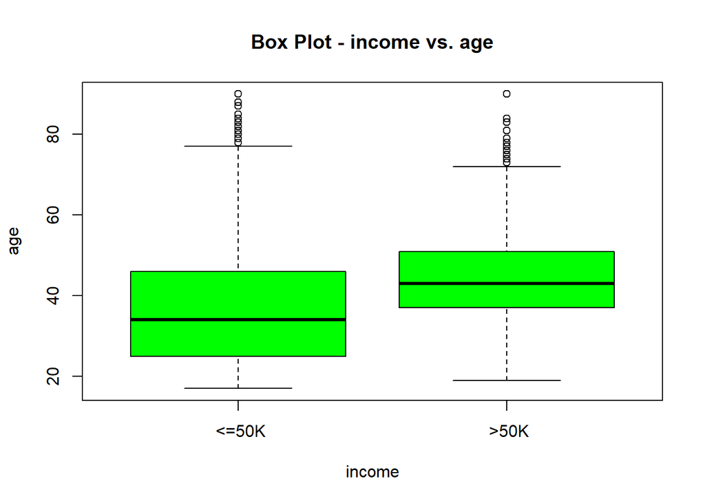

```
##
##  Welch Two Sample t-test
##
## data:  df[, v] by df[, target_var]
## t = -44.779, df = 13798, p-value < 2.2e-16
## alternative hypothesis: true difference in means between group  <=50K and group  >50K is not equal to 0
## 95 percent confidence interval:
##  -7.766657 -7.115217
## sample estimates:
## mean in group  <=50K  mean in group  >50K
##             36.80541             44.24634
##
## [1] "*************fnlwgt*************"
```

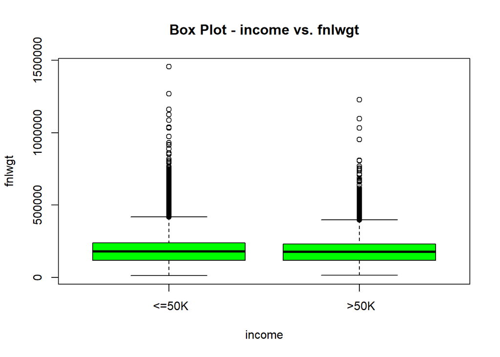

```
##
##  Welch Two Sample t-test
##
## data:  df[, v] by df[, target_var]
## t = 1.2322, df = 10617, p-value = 0.2179
## alternative hypothesis: true difference in means between group  <=50K and group  >50K is not equal to 0
## 95 percent confidence interval:
##  -1103.947  4840.712
## sample estimates:
## mean in group  <=50K  mean in group  >50K
##             190129.1             188260.7
##
## [1] "*************education_num*************"
```

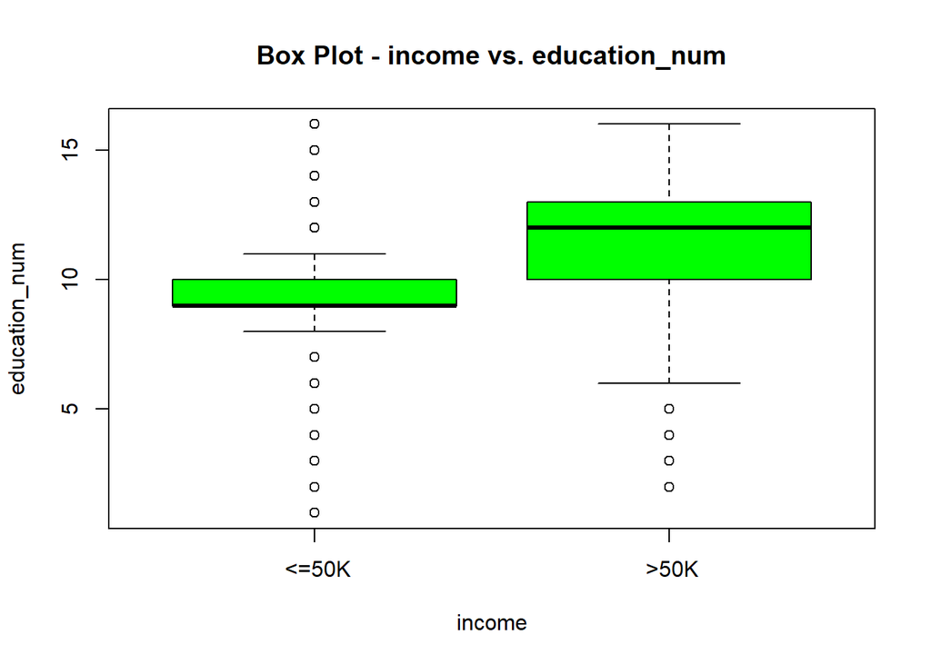

```
##
##  Welch Two Sample t-test
##
## data:  df[, v] by df[, target_var]
## t = -57.734, df = 10582, p-value < 2.2e-16
## alternative hypothesis: true difference in means between group  <=50K and group  >50K is not equal to 0
## 95 percent confidence interval:
##  -2.079213 -1.942663
## sample estimates:
## mean in group  <=50K  mean in group  >50K
##             9.595682            11.606621
##
## [1] "*************capital_gain*************"
```

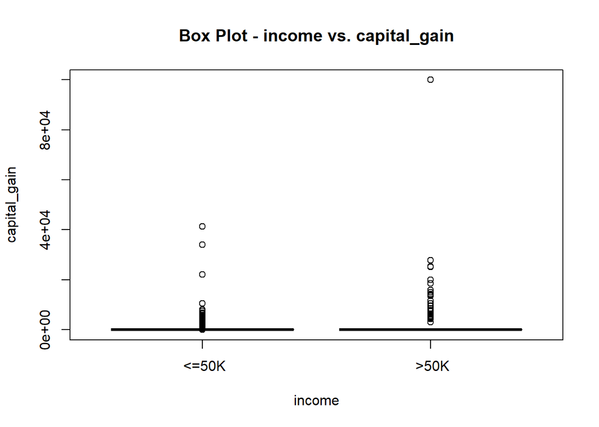

```
##
##  Welch Two Sample t-test
##
## data:  df[, v] by df[, target_var]
## t = -20.818, df = 6237.3, p-value < 2.2e-16
## alternative hypothesis: true difference in means between group  <=50K and group  >50K is not equal to 0
## 95 percent confidence interval:
##  -4305.170 -3564.146
## sample estimates:
## mean in group  <=50K  mean in group  >50K
##             146.9062            4081.5642
##
## [1] "*************capital_loss*************"
```

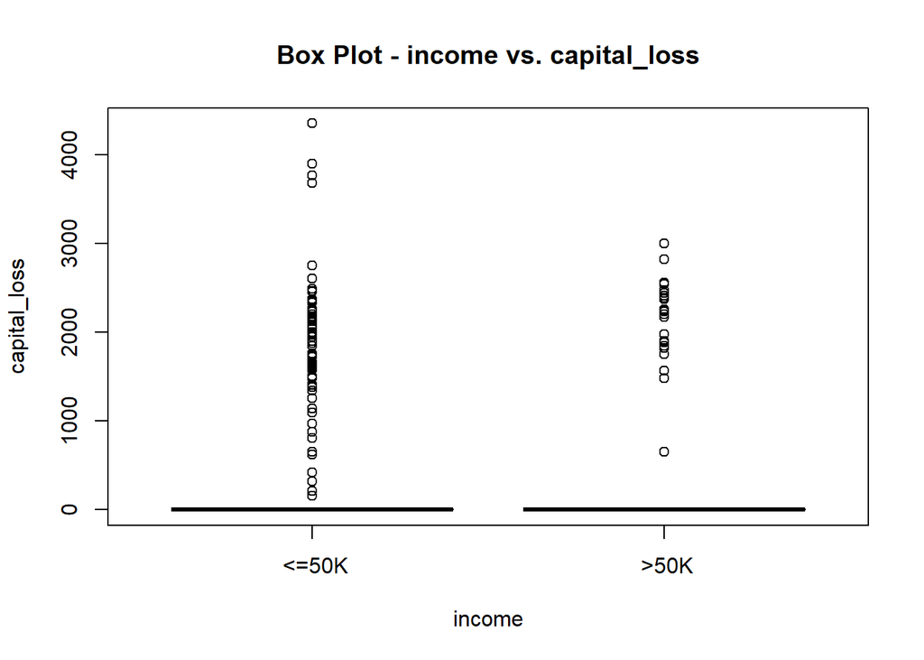

```
##
##  Welch Two Sample t-test
##
## data:  df[, v] by df[, target_var]
## t = -17.226, df = 7365.3, p-value < 2.2e-16
## alternative hypothesis: true difference in means between group  <=50K and group  >50K is not equal to 0
## 95 percent confidence interval:
##  -148.1840 -117.9039
## sample estimates:
## mean in group  <=50K  mean in group  >50K
##             53.53712            186.58107
##
## [1] "*************hours_per_week*************"
```

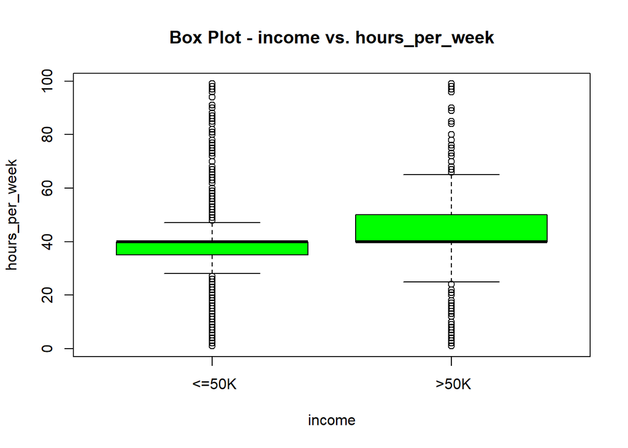

```
##
##  Welch Two Sample t-test
##
## data:  df[, v] by df[, target_var]
## t = -40.56, df = 11472, p-value < 2.2e-16
## alternative hypothesis: true difference in means between group  <=50K and group  >50K is not equal to 0
## 95 percent confidence interval:
##  -6.998332 -6.353086
## sample estimates:
## mean in group  <=50K  mean in group  >50K
##             38.81746             45.49317
```

```r
# Once again reusing code from the previous assignements

## Reused My Code from the Assignment 1 - automation
## and made it into a function

# Nuerical vs Categ(2 types) - Two test
diagnose_association_numerical <- function(df,
                                           numer_vars,
                                           target_var,
                                           signif_val = 0.05) {
  numer_p_value_dataframe <- data.frame()
  for(v in numer_vars){

    print(paste("*************",v,"*************",sep= ""))
    plot(df[,v]~df[, target_var],
       col="green",
       main = paste("Box Plot - ",target_var," vs. ",v, sep = ""),
       xlab = target_var,
       ylab = v)

    # t.test - to test whether a categorical variable with two levels is
    # independent of a continuous numerical variable
    numer_Test_details = t.test(df[,v] ~ df[,target_var],
                                alternative = "two.sided")
    print(numer_Test_details)
    numer_p_value_dataframe <- rbind(
      numer_p_value_dataframe,
      data.frame(feature1 = target_var,
                 feature2 = v,
                 p.value = numer_Test_details["p.value"],
                 test_name = "ttest"))
    }

  numer_p_value_dataframe$signif <- signif_val
  numer_p_value_dataframe$result <- (
    ifelse(
      numer_p_value_dataframe$p.value < numer_p_value_dataframe$signif,
      "pass", "fail" ))

  return(numer_p_value_dataframe)

}

# Categorical vs Categoricl - ChiSQ Test
diagnose_association_factor <- function(df,
                                        factor_vars,
                                        target_var,
                                        signif_val = 0.05) {

  factor_p_value_dataframe <- data.frame()
  for(v in factor_vars[(!factor_vars %in% c(target_var))]){
    print(paste("--------------------",v,"--------------------"))
    ctable <- table(df[, v], df[, target_var])
    mosaicplot(ctable,
               ylab = target_var,
               xlab = v,
               main = paste("Mosaic graph of",target_var,"vs",v,sep = " "))
    print(chisq.test(ctable))
    factor_Test_details = chisq.test(ctable)
    factor_p_value_dataframe <- rbind(
      factor_p_value_dataframe,
      data.frame(feature1 = target_var,
                 feature2 = v,
                 p.value = factor_Test_details["p.value"],
                 test_name = "chisq"))
    }

  factor_p_value_dataframe$signif <- signif_val
  factor_p_value_dataframe$result <- (
    ifelse(
      factor_p_value_dataframe$p.value < factor_p_value_dataframe$signif,
      "pass", "fail" ))

  return(factor_p_value_dataframe)
}

target_DV = "income"

assoc_num_df <- diagnose_association_numerical(df = adult_data_train,
                                               numer_vars = numeric_cols,
                                               target_var = target_DV)
```

```r
assoc_fac_df <- diagnose_association_factor(df = adult_data_train,
                                            factor_vars = factor_cols,
                                            target_var = target_DV)
```

```
## [1] "-------------------- workclass --------------------"
```

```
##
##  Pearson's Chi-squared test
##
## data:  ctable
## X-squared = 823.46, df = 8, p-value < 2.2e-16
```

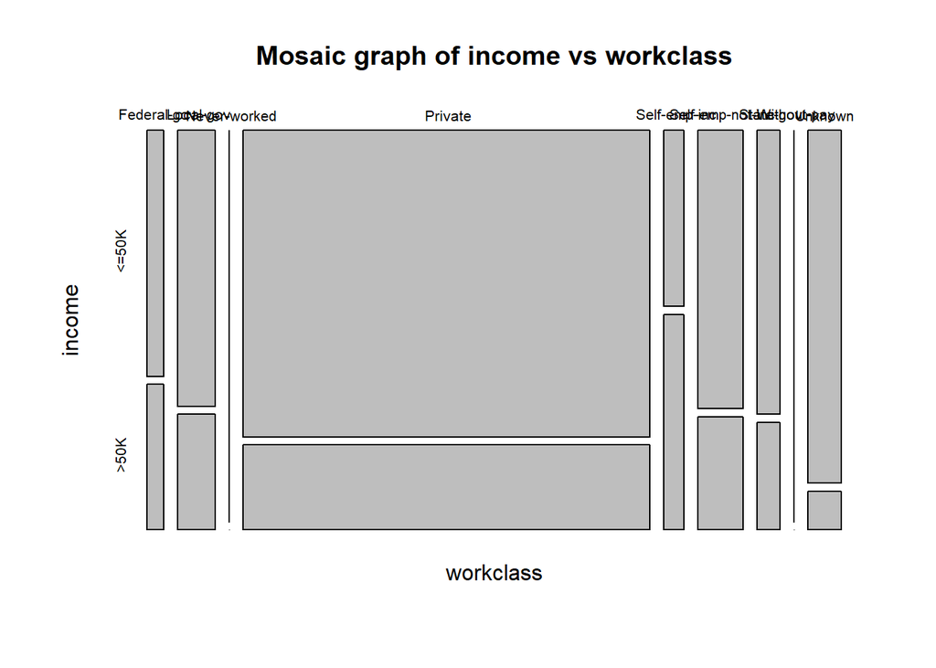

```
## [1] "-------------------- education --------------------"
```

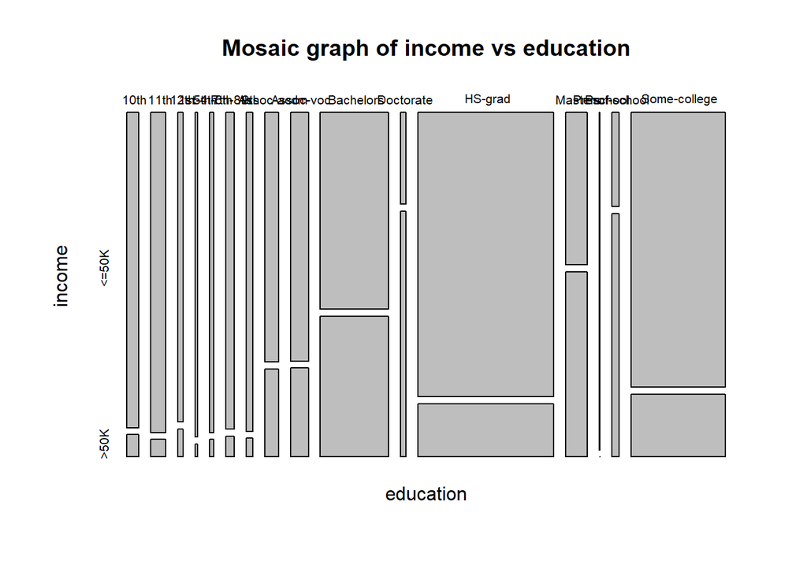

```
##
##  Pearson's Chi-squared test
##
## data:  ctable
## X-squared = 3500.8, df = 15, p-value < 2.2e-16
##
## [1] "-------------------- marital_status --------------------"
```

```
##
##  Pearson's Chi-squared test
##
## data:  ctable
## X-squared = 5162.9, df = 6, p-value < 2.2e-16
```

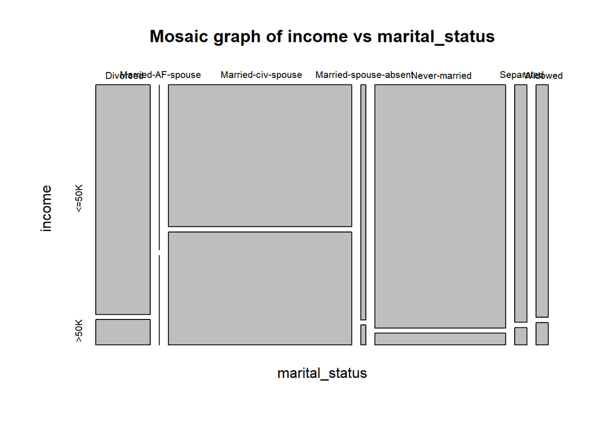

```
## [1] "-------------------- occupation --------------------"
```

```
##
##  Pearson's Chi-squared test
##
## data:  ctable
## X-squared = 3217.3, df = 14, p-value < 2.2e-16
```

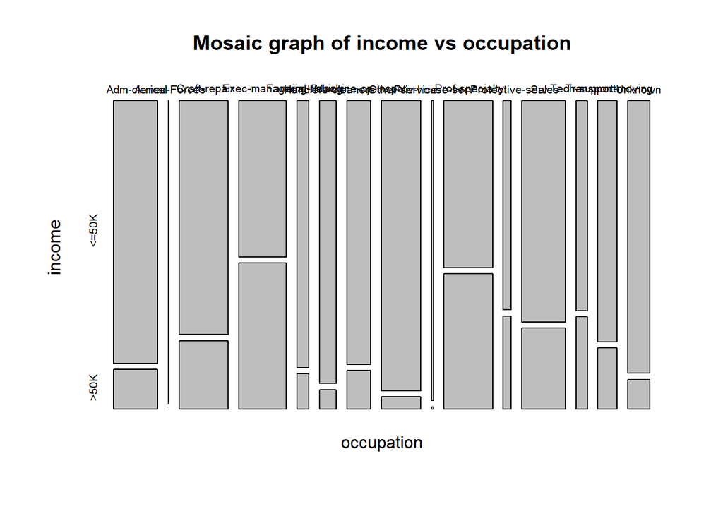

```
## [1] "-------------------- relationship --------------------"
```

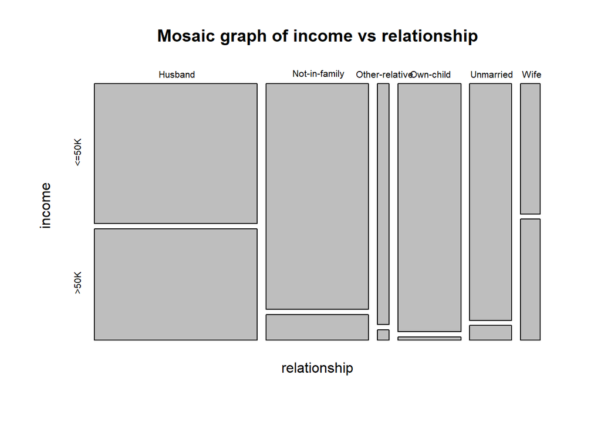

```
##
##  Pearson's Chi-squared test
##
## data:  ctable
## X-squared = 5316.4, df = 5, p-value < 2.2e-16
##
## [1] "-------------------- race --------------------"
```

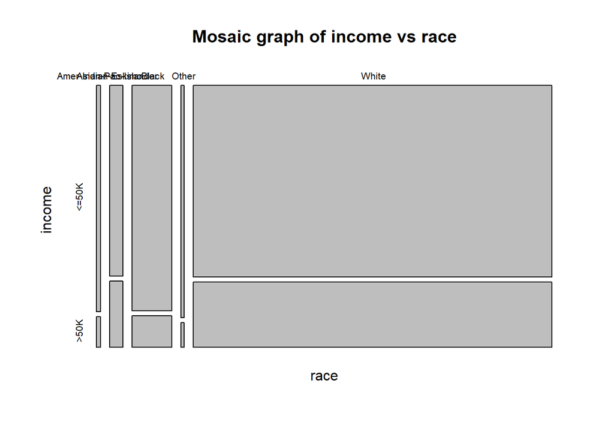

```
##
##  Pearson's Chi-squared test
##
## data:  ctable
## X-squared = 257.67, df = 4, p-value < 2.2e-16
##
## [1] "-------------------- sex --------------------"
```

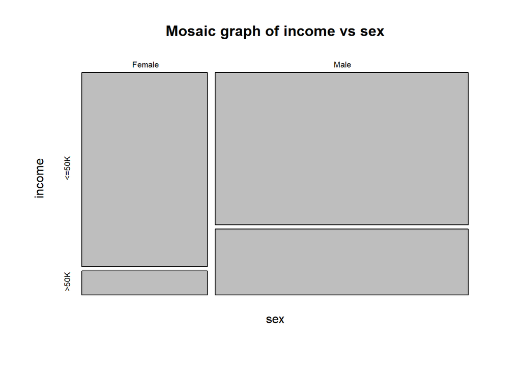

```
##
##  Pearson's Chi-squared test with Yates' continuity correction
##
## data:  ctable
## X-squared = 1170.6, df = 1, p-value < 2.2e-16
##
## [1] "-------------------- native_country --------------------"
```

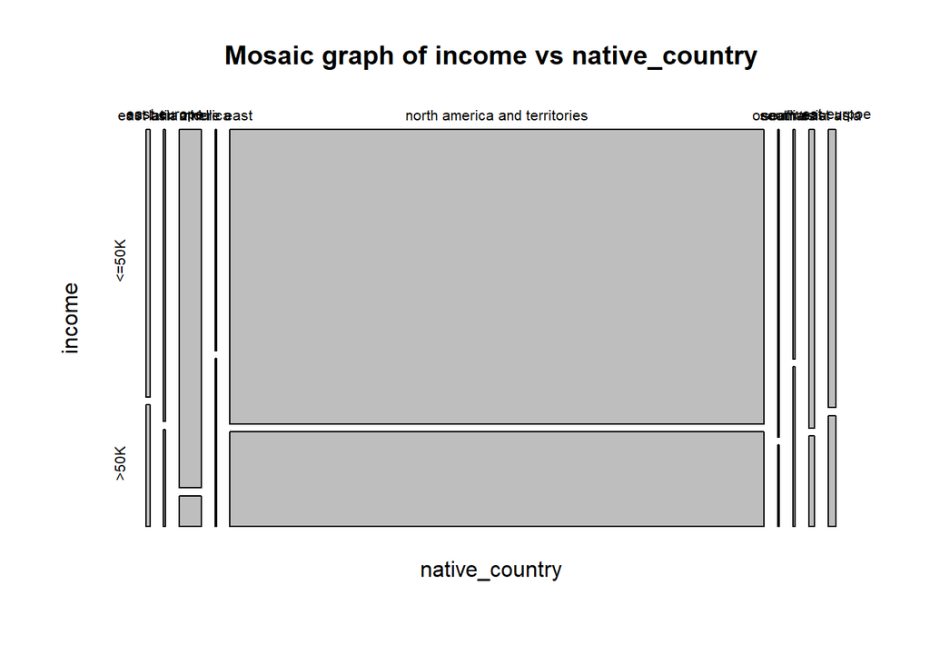

```
##
##  Pearson's Chi-squared test
##
## data:  ctable
## X-squared = 176.3, df = 8, p-value < 2.2e-16
```

```r
qualified_features_data <- assoc_num_df %>% rbind.data.frame(assoc_fac_df)

qualified_features_data
```

```
##    feature1       feature2       p.value test_name signif result
## 1    income            age  0.000000e+00     ttest   0.05   pass
## 2    income         fnlwgt  2.179172e-01     ttest   0.05   fail
## 3    income  education_num  0.000000e+00     ttest   0.05   pass
## 4    income   capital_gain  4.113356e-93     ttest   0.05   pass
## 5    income   capital_loss  3.170872e-65     ttest   0.05   pass
## 6    income hours_per_week  0.000000e+00     ttest   0.05   pass
## 7    income      workclass 1.810436e-172     chisq   0.05   pass
## 8    income      education  0.000000e+00     chisq   0.05   pass
## 9    income marital_status  0.000000e+00     chisq   0.05   pass
## 10   income     occupation  0.000000e+00     chisq   0.05   pass
## 11   income   relationship  0.000000e+00     chisq   0.05   pass
## 12   income           race  1.445786e-54     chisq   0.05   pass
## 13   income            sex 1.469375e-256     chisq   0.05   pass
## 14   income native_country  6.152309e-34     chisq   0.05   pass
```

“fnlwgt” - this particular feature doesn’t have association with our target variable. And I shall rmove this variable from the features list / dataframe.

```r
# Removing the variable from the
unqualified_feature <- qualified_features_data[(qualified_features_data$result == "fail"), "feature2"]

# Discarding that feature from the datasets
adult_data_train <- adult_data_train %>% select(-one_of(unqualified_feature))
adult_data_test <- adult_data_test %>% select(-one_of(unqualified_feature))
```

##### 7. (2pt) Train a logistic regression model on the train data (preprocessed and transformed using above steps) using the glm package and use it to predict “income” for the test data. Note: As explained in the lectures, “predict” method will return predicted probabilities. To convert them to labels, you need to use some threshold ( typically set as 50%) and if the predicted probability is greater than 50% you predict income>50K; otherwise predict income<=50K ( please review the example in lecture 7.2).

I am reusing the codes from the lecture notes.

```r
# Training the model
# the equatin is income varable is function all other variables
log_reg_model <- glm(income~., data = adult_data_train, family = "binomial")
summary(log_reg_model)
```

```
##
## Call:
## glm(formula = income ~ ., family = "binomial", data = adult_data_train)
##
## Deviance Residuals:
##     Min       1Q   Median       3Q      Max
## -5.0521  -0.5103  -0.1848  -0.0306   3.3921
##
## Coefficients: (2 not defined because of singularities)
##                                               Estimate Std. Error z value
## (Intercept)                                 -7.826e+00  5.483e-01 -14.272
## age                                          2.641e-02  1.841e-03  14.348
## workclass Local-gov                         -5.873e-01  1.261e-01  -4.656
## workclass Never-worked                      -1.223e+01  3.666e+02  -0.033
## workclass Private                           -4.270e-01  1.051e-01  -4.061
## workclass Self-emp-inc                      -2.842e-01  1.373e-01  -2.070
## workclass Self-emp-not-inc                  -9.154e-01  1.227e-01  -7.461
## workclass State-gov                         -6.940e-01  1.396e-01  -4.973
## workclass Without-pay                       -1.317e+01  2.207e+02  -0.060
## workclassUnknown                            -1.196e+00  1.584e-01  -7.553
## education 11th                               1.750e-01  2.354e-01   0.743
## education 12th                               5.853e-01  2.923e-01   2.003
## education 1st-4th                           -4.165e-01  5.346e-01  -0.779
## education 5th-6th                           -1.603e-01  3.479e-01  -0.461
## education 7th-8th                           -5.580e-01  2.621e-01  -2.129
## education 9th                               -2.091e-01  2.876e-01  -0.727
## education Assoc-acdm                         1.488e+00  1.965e-01   7.572
## education Assoc-voc                          1.371e+00  1.897e-01   7.231
## education Bachelors                          1.959e+00  1.768e-01  11.080
## education Doctorate                          2.963e+00  2.379e-01  12.456
## education HS-grad                            8.355e-01  1.724e-01   4.846
## education Masters                            2.277e+00  1.886e-01  12.075
## education Preschool                         -1.081e+01  1.238e+02  -0.087
## education Prof-school                        2.807e+00  2.219e-01  12.646
## education Some-college                       1.167e+00  1.748e-01   6.675
## education_num                                       NA         NA      NA
## marital_status Married-AF-spouse             2.116e+00  6.597e-01   3.207
## marital_status Married-civ-spouse            2.131e+00  2.969e-01   7.180
## marital_status Married-spouse-absent         7.487e-02  2.558e-01   0.293
## marital_status Never-married                -4.877e-01  9.759e-02  -4.998
```

[output cut: 100 more lines]

```
## native_countrynorth america and territories 0.394798
## native_countryoceania                       0.209669
## native_countrysouth asia                    0.722100
## native_countrysouth east asia               0.483113
## native_countrywest eurpoe                   0.361313
## ---
## Signif. codes:  0 '***' 0.001 '**' 0.01 '*' 0.05 '.' 0.1 ' ' 1
##
## (Dispersion parameter for binomial family taken to be 1)
##
##     Null deviance: 28644  on 26048  degrees of freedom
## Residual deviance: 16510  on 25984  degrees of freedom
## AIC: 16640
##
## Number of Fisher Scoring iterations: 13
```

```r
# Testing the model on the test dataset
log_reg_prdiction <- predict(object = log_reg_model, adult_data_test, type = "response")
head(log_reg_prdiction)
```

```
##         12         14         25         34         35         40
## 0.36211499 0.08520518 0.05953377 0.19780112 0.03311808 0.41841612
```

```r
# Let us check the prodcitions
log_reg_predicted_label = ifelse(log_reg_prdiction > 0.5, " >50K", " <=50K")

# Checimng hte prediciton
actual_label <- adult_data_test$income
predicted_label <- log_reg_predicted_label
CONFUSION_MATRIX_1 = table(predicted_label, actual_label)

error <- (CONFUSION_MATRIX_1[1,2]+CONFUSION_MATRIX_1[2,1]) / sum(CONFUSION_MATRIX_1)
```

```r
# RE USING CODES FROM THE OLD ASSIGNEMNET 2

performance_evaluation_fn <- function(confusion_matrix) {

  # Extract the values from the confusion matrix
  true_negative <- confusion_matrix[1, 1]  # Actual 'no', Predicted 'no' - TN
  false_positive <- confusion_matrix[1, 2] # Actual 'no', Predicted 'yes' - FP
  false_negative <- confusion_matrix[2, 1] # Actual 'yes', Predicted 'no' - FN
  true_positive <- confusion_matrix[2, 2]  # Actual 'yes', Predicted 'yes' - TP

  Precision_Value = true_positive/ (true_positive + false_positive)
  Recall_Value = true_positive/ (true_positive + false_negative)
  Error_Value = (false_positive + false_negative) / sum(confusion_matrix)

  return(list("Error_Value" = Error_Value, "Precision_Value" = Precision_Value, "Recall_Value" = Recall_Value))
}

# Displaying performance
log_reg_performance <- performance_evaluation_fn(confusion_matrix = CONFUSION_MATRIX_1)
print(log_reg_performance)
```

```
## $Error_Value
## [1] 0.1501843
##
## $Precision_Value
## [1] 0.605686
##
## $Recall_Value
## [1] 0.7424242
```

##### 9.(3pt) The target variable “income” is imbalanced; the number of adults who make <=50 is three times more than the number of adults who make >50K. Most classification models trained on imbalanced data are biased towards predicting the majority class ( income<=50K in this case) and yield a higher classification error on the minority class (income >50K).

###### One way to deal with class imbalance problem is to down-sample the majority class; meaning randomly sample the observations in the majority class to make it the same size as the minority class.

###### The downside of this approach is that for smaller datasets, removing data will result in significant loss of information and lower performance. In Module 12, we will learn about other techniques to deal with data imbalance without removing information, but for this assignment, we use down- sampling in an attempt to address data imbalance.

###### Note: Down-sampling should only be done on the training data and the test data should have the original imbalance distribution. You can downsample as follows:

- Divide your training data into two sets, adults who make <=50K and the ones who make >50K.
- Suppose that the >50K set has m elements. Take a sample of size m from the <=50K set.
  - You can use “sample” from the base package to sample the rows or alternatively, you can use the method “sample_n” from dplyr package to directly sample the dataframe
- Combine the above sample with the >50K set. You can use “rbind” function to combine the rows in two or more dataframes. This will give you a balanced training data with the same observations in >50K and <=50K classes.
- Re-train the logistic regression model on the balanced training data and evaluate it on the test data. Compare the total error, precision, and recall for the <=50K class and >=50K classes with the previous model. Which model does better at predicting each class?

I am going to use all the codes in the same R code chunk. Yes, I am going to downsample.

```r
# Splitting the training data set
adult_data_train_high_income <- adult_data_train %>% filter(income == " >50K")
adult_data_train_low_income <- adult_data_train %>% filter(income == " <=50K")

# Shuffling the records
adult_data_train_low_income <- adult_data_train_low_income %>% sample_n(nrow(adult_data_train_high_income), replace = TRUE)

# train data balanced
adult_data_train_2 <- adult_data_train_high_income %>% rbind.data.frame(adult_data_train_low_income)

# Training the model for the balanced dataset
log_reg_model_2 <- glm(income~., data = adult_data_train_2, family = "binomial")
# Summary if the model
summary(log_reg_model_2)
```

```
##
## Call:
## glm(formula = income ~ ., family = "binomial", data = adult_data_train_2)
##
## Deviance Residuals:
##     Min       1Q   Median       3Q      Max
## -5.3000  -0.5157   0.0000   0.6256   3.0951
##
## Coefficients: (2 not defined because of singularities)
##                                               Estimate Std. Error z value
## (Intercept)                                 -7.262e+00  6.819e-01 -10.649
## age                                          2.882e-02  2.486e-03  11.592
## workclass Local-gov                         -7.606e-01  1.750e-01  -4.346
## workclass Never-worked                      -1.537e+01  8.827e+02  -0.017
## workclass Private                           -6.184e-01  1.488e-01  -4.156
## workclass Self-emp-inc                      -5.189e-01  1.937e-01  -2.679
## workclass Self-emp-not-inc                  -1.013e+00  1.703e-01  -5.947
## workclass State-gov                         -8.337e-01  1.913e-01  -4.358
## workclass Without-pay                       -1.443e+01  2.680e+02  -0.054
## workclassUnknown                            -1.404e+00  2.056e-01  -6.829
## education 11th                               1.571e-01  2.776e-01   0.566
## education 12th                               4.563e-01  3.503e-01   1.302
## education 1st-4th                           -3.555e-01  6.171e-01  -0.576
## education 5th-6th                            1.396e-02  4.161e-01   0.034
## education 7th-8th                           -2.963e-01  3.088e-01  -0.959
## education 9th                               -3.208e-01  3.274e-01  -0.980
## education Assoc-acdm                         1.398e+00  2.373e-01   5.893
## education Assoc-voc                          1.327e+00  2.268e-01   5.849
## education Bachelors                          1.880e+00  2.094e-01   8.976
## education Doctorate                          3.098e+00  3.216e-01   9.631
## education HS-grad                            8.854e-01  2.022e-01   4.379
## education Masters                            2.372e+00  2.317e-01  10.235
## education Preschool                         -1.234e+01  2.930e+02  -0.042
## education Prof-school                        2.527e+00  2.801e-01   9.022
## education Some-college                       1.132e+00  2.056e-01   5.506
## education_num                                       NA         NA      NA
## marital_status Married-AF-spouse             2.833e+00  9.122e-01   3.105
## marital_status Married-civ-spouse            2.286e+00  3.520e-01   6.496
## marital_status Married-spouse-absent         1.456e-01  3.066e-01   0.475
## marital_status Never-married                -5.680e-01  1.147e-01  -4.953
```

[output cut: 100 more lines]

```
## native_countrynorth america and territories 0.100065
## native_countryoceania                       0.919563
## native_countrysouth asia                    0.128864
## native_countrysouth east asia               0.058660 .
## native_countrywest eurpoe                   0.124245
## ---
## Signif. codes:  0 '***' 0.001 '**' 0.01 '*' 0.05 '.' 0.1 ' ' 1
##
## (Dispersion parameter for binomial family taken to be 1)
##
##     Null deviance: 17253.8  on 12445  degrees of freedom
## Residual deviance:  9587.9  on 12381  degrees of freedom
## AIC: 9717.9
##
## Number of Fisher Scoring iterations: 13
```

```r
# Testing the model on the test dataset
log_reg_prdiction_2 <- predict(object = log_reg_model_2, adult_data_test, type = "response")
head(log_reg_prdiction_2)
```

```
##         12         14         25         34         35         40
## 0.80082263 0.22362111 0.15783146 0.49282528 0.09229358 0.71782656
```

```r
# Let us check the prodcitions
log_reg_predicted_label_2 = ifelse(log_reg_prdiction_2 > 0.5, " >50K", " <=50K")

# Checimng hte prediciton
actual_label <- adult_data_test$income
predicted_label <- log_reg_predicted_label_2
CONFUSION_MATRIX_2 = table(predicted_label, actual_label)

error <- (CONFUSION_MATRIX_2[1,2]+CONFUSION_MATRIX_2[2,1]) / sum(CONFUSION_MATRIX_2)

# Final Performances
log_reg_performance_2 <- performance_evaluation_fn(confusion_matrix = CONFUSION_MATRIX_2)
print(log_reg_performance_2)
```

```
## $Error_Value
## [1] 0.1844287
##
## $Precision_Value
## [1] 0.855377
##
## $Recall_Value
## [1] 0.5886857
```

##### 10. (3pt) Repeat steps 7-9 above but this time, use a C5.0 decision tree model to predict “income” instead of the logistic regression model (use trials=30 for boosting multiple decision trees (see an example in slide 44, module 6) . Compare the logistic regression model with the boosted C5.0 model.

I am going to use the same set if features and reuse the code chunks from the lecture notes. On with imbalanced dataset and another modeling exercise with balanced dataset. Allsteps form 7-9 wil be combined in one code chunk. Since we have 2 types of training datasets : balanced and imbalanced, we will use both of them.

```r
# Let us perform decision tree modeling

# Imbalanced Data set
decision_tree_boost_model <- C5.0(x = adult_data_train %>% select(-one_of("income")),
                                  adult_data_train$income,
                                  trials = 30)
decision_tree_boost_prediction <- predict(decision_tree_boost_model, adult_data_test)

# Balanced Dataset
decision_tree_boost_model_2 <- C5.0(x = adult_data_train_2 %>% select(-one_of("income")),
                                    adult_data_train_2$income,
                                    trials = 30)
decision_tree_boost_prediction_2 <- predict(decision_tree_boost_model_2, adult_data_test)


# Checimng hte prediciton
actual_label <- adult_data_test$income
predicted_label <- decision_tree_boost_prediction
predicted_label_2 <- decision_tree_boost_prediction_2
CONFUSION_MATRIX_3 = table(predicted_label, actual_label)
CONFUSION_MATRIX_4 = table(predicted_label_2, actual_label)

# Final Performances
decision_tree_boost_performance <- performance_evaluation_fn(confusion_matrix = CONFUSION_MATRIX_3)
decision_tree_boost_performance_2 <- performance_evaluation_fn(confusion_matrix = CONFUSION_MATRIX_4)

# Final values
print(decision_tree_boost_performance)
```

```
## $Error_Value
## [1] 0.1308354
##
## $Precision_Value
## [1] 0.6718171
##
## $Recall_Value
## [1] 0.772017
```

```r
print("--------Downsampled-----")
```

```
## [1] "--------Downsampled-----"
```

```r
print(decision_tree_boost_performance_2)
```

```
## $Error_Value
## [1] 0.1733722
##
## $Precision_Value
## [1] 0.8615575
##
## $Recall_Value
## [1] 0.6063506
```

Below is you see the values form the original logistiv regression.

$Error_Value [1] 0.1501843

$Precision_Value [1] 0.605686

$Recall_Value [1] 0.7424242

When we compare the decisoin tree and logistic regression, we can conclude that the decision tree has given us better results. Ther error is lesseer the lo. reg model and preciosn is better the origianl log. reg. model.

# Problem2—Predicting Student Performance

```r
## Essential modules to import
library(dplyr)
library(caret)
library(leaps)
```

### For this problem we are going to use UCI’s student performance dataset. The dataset is a recording of student grades in math and language and includes attributes related to student demographics and school related features. Click on the above link, then go to “Data Folder” and download and unzip “student.zip”. You will be using student-mat.csv file. The goal is to create a regression model to forecast student final grade in math “G3” based on the other attributes.

##### 11. (0.5pt) Read the dataset into a dataframe. Ensure that you are using a correct delimiter to read the data correctly and set the “sep” option in read.csv accordingly.

```r
# Input data paths
student_mat_data_path <- "D:/UIS/Studies/Semester4/CSC532/Assignments/Assignment3/regression_project/input_datasets/student+performance/student/student-mat.csv"
```

```r
# Reading data
student_mat_data <- read.csv(file = student_mat_data_path,
                             header = TRUE,
                             sep = ";")
```

##### 12. (2pt) Explore the dataset. More specifically, answer the following questions:

###### a. Is there any missing values in the dataset?

```r
# Let us check if there are any null / missing values
cat(paste(
  "Prelimiary Check for the existence of null values : ",
  sum(is.na(student_mat_data)),
  sep = ""))
```

```
## Prelimiary Check for the existence of null values : 0
```

```r
# let us check the null values values in different formats
student_mat_data_NA_Check <- student_mat_data
student_mat_data_NA_Check[student_mat_data_NA_Check %in% c("NA", "N/A", "NULL", "", "."," ","?")] <- NA
print(sum(is.na(student_mat_data_NA_Check)))
```

```
## [1] 0
```

So basically there are no missign values, hence we are gonna proceed further with the assignment questions.

When checked this link: https://archive.ics.uci.edu/dataset/320/student+performance I was able to make sure that my investigation is right because the website says no maiisgin values.

###### b. Which variables are associated with the target variable G3? To answer this question, use appropriate plots and test statistics based on variable types. You can do this one by one for all variables or write a loop that applies appropriate statistic tests based on variable types. Either approach is fine.

To understand that we would first have to undertand the strucutre of the dataframe and get summary of the dataframe.

```r
# Structure fo the dataframe
str(student_mat_data)
```

```
## 'data.frame':    395 obs. of  33 variables:
##  $ school    : chr  "GP" "GP" "GP" "GP" ...
##  $ sex       : chr  "F" "F" "F" "F" ...
##  $ age       : int  18 17 15 15 16 16 16 17 15 15 ...
##  $ address   : chr  "U" "U" "U" "U" ...
##  $ famsize   : chr  "GT3" "GT3" "LE3" "GT3" ...
##  $ Pstatus   : chr  "A" "T" "T" "T" ...
##  $ Medu      : int  4 1 1 4 3 4 2 4 3 3 ...
##  $ Fedu      : int  4 1 1 2 3 3 2 4 2 4 ...
##  $ Mjob      : chr  "at_home" "at_home" "at_home" "health" ...
##  $ Fjob      : chr  "teacher" "other" "other" "services" ...
##  $ reason    : chr  "course" "course" "other" "home" ...
##  $ guardian  : chr  "mother" "father" "mother" "mother" ...
##  $ traveltime: int  2 1 1 1 1 1 1 2 1 1 ...
##  $ studytime : int  2 2 2 3 2 2 2 2 2 2 ...
```

[output cut: 19 more lines]

```r
# Summary
summary(student_mat_data)
```

```
##     school              sex                 age         address
##  Length:395         Length:395         Min.   :15.0   Length:395
##  Class :character   Class :character   1st Qu.:16.0   Class :character
##  Mode  :character   Mode  :character   Median :17.0   Mode  :character
##                                        Mean   :16.7
##                                        3rd Qu.:18.0
##                                        Max.   :22.0
##    famsize            Pstatus               Medu            Fedu
##  Length:395         Length:395         Min.   :0.000   Min.   :0.000
##  Class :character   Class :character   1st Qu.:2.000   1st Qu.:2.000
##  Mode  :character   Mode  :character   Median :3.000   Median :2.000
##                                        Mean   :2.749   Mean   :2.522
##                                        3rd Qu.:4.000   3rd Qu.:3.000
##                                        Max.   :4.000   Max.   :4.000
##      Mjob               Fjob              reason            guardian
##  Length:395         Length:395         Length:395         Length:395
##  Class :character   Class :character   Class :character   Class :character
##  Mode  :character   Mode  :character   Mode  :character   Mode  :character
##
##
##
##    traveltime      studytime        failures       schoolsup
##  Min.   :1.000   Min.   :1.000   Min.   :0.0000   Length:395
##  1st Qu.:1.000   1st Qu.:1.000   1st Qu.:0.0000   Class :character
##  Median :1.000   Median :2.000   Median :0.0000   Mode  :character
##  Mean   :1.448   Mean   :2.035   Mean   :0.3342
##  3rd Qu.:2.000   3rd Qu.:2.000   3rd Qu.:0.0000
##  Max.   :4.000   Max.   :4.000   Max.   :3.0000
##     famsup              paid            activities          nursery
##  Length:395         Length:395         Length:395         Length:395
##  Class :character   Class :character   Class :character   Class :character
##  Mode  :character   Mode  :character   Mode  :character   Mode  :character
##
##
##
##     higher            internet           romantic             famrel
##  Length:395         Length:395         Length:395         Min.   :1.000
##  Class :character   Class :character   Class :character   1st Qu.:4.000
##  Mode  :character   Mode  :character   Mode  :character   Median :4.000
##                                                           Mean   :3.944
```

[output cut: 8 more lines]

```
##  Max.   :5.000   Max.   :5.000   Max.   :5.000   Max.   :5.000
##      health         absences            G1              G2
##  Min.   :1.000   Min.   : 0.000   Min.   : 3.00   Min.   : 0.00
##  1st Qu.:3.000   1st Qu.: 0.000   1st Qu.: 8.00   1st Qu.: 9.00
##  Median :4.000   Median : 4.000   Median :11.00   Median :11.00
##  Mean   :3.554   Mean   : 5.709   Mean   :10.91   Mean   :10.71
##  3rd Qu.:5.000   3rd Qu.: 8.000   3rd Qu.:13.00   3rd Qu.:13.00
##  Max.   :5.000   Max.   :75.000   Max.   :19.00   Max.   :19.00
##        G3
##  Min.   : 0.00
##  1st Qu.: 8.00
##  Median :11.00
##  Mean   :10.42
##  3rd Qu.:14.00
##  Max.   :20.00
```

There are 33 features. Let us check the columns and data types.

```r
# Code resued from my Assignemnetn 2 solution
numeric_cols <- colnames(student_mat_data)[sapply(student_mat_data, is.numeric)]
factor_cols <- colnames(student_mat_data)[sapply(student_mat_data, is.factor)]
character_cols <- colnames(student_mat_data)[sapply(student_mat_data, is.character)]

# Checking the column names
cat("Numeric columns: \n------\n", paste(numeric_cols, collapse = ", "), "\n")
```

```
## Numeric columns:
## ------
##  age, Medu, Fedu, traveltime, studytime, failures, famrel, freetime, goout, Dalc, Walc, health, absences, G1, G2, G3
```

```r
cat("Factor columns: \n------\n", paste(factor_cols, collapse = ", "), "\n")
```

```
## Factor columns:
## ------
##
```

```r
cat("Character columns: \n------\n", paste(character_cols, collapse = ", "), "\n")
```

```
## Character columns:
## ------
##  school, sex, address, famsize, Pstatus, Mjob, Fjob, reason, guardian, schoolsup, famsup, paid, activities, nursery, higher, internet, romantic
```

Since we don’t have factor variables hence let us make all the character variables to factor nominal variables.

```r
# # Let us select each character variable and make it a factor variable
# Making all the cahracter variables to factors, I don't want them to have levels.
for(cc in character_cols) {
  student_mat_data[, cc] <- factor(student_mat_data[, cc])
}
```

Now let us check all the variables datatype.

```r
# Code resued from my Assignemnetn 2 solution
numeric_cols <- colnames(student_mat_data)[sapply(student_mat_data, is.numeric)]
factor_cols <- colnames(student_mat_data)[sapply(student_mat_data, is.factor)]
character_cols <- colnames(student_mat_data)[sapply(student_mat_data, is.character)]

# Checking the column names
cat("Numeric columns: \n------\n", paste(numeric_cols, collapse = ", "), "\n")
```

```
## Numeric columns:
## ------
##  age, Medu, Fedu, traveltime, studytime, failures, famrel, freetime, goout, Dalc, Walc, health, absences, G1, G2, G3
```

```r
cat("Factor columns: \n------\n", paste(factor_cols, collapse = ", "), "\n")
```

```
## Factor columns:
## ------
##  school, sex, address, famsize, Pstatus, Mjob, Fjob, reason, guardian, schoolsup, famsup, paid, activities, nursery, higher, internet, romantic
```

```r
cat("Character columns: \n------\n", paste(character_cols, collapse = ", "), "\n")
```

```
## Character columns:
## ------
##
```

```r
## Reused My Code from the Assignment 1 - automation
## and made it into a function

# Nuerical vs Numerical - Correlation Test
diagnose_association_numerical <- function(df,
                                           numer_vars,
                                           target_var,
                                           signif_val = 0.05) {
  numer_p_value_dataframe <- data.frame()

  for(v in numer_vars[(!numer_vars %in% c(target_var))]){

    print(paste("*************",v,"*************",sep= ""))
    plot(x = df[, target_var],
         y = df[,v],
         main = paste("Scatter Plot - ",target_var," vs. ",v, sep = ""),
         xlab = target_var,
         ylab = v)

    print(paste("Simple correlation check between the variables : ", cor(df[, target_var], df[, v])))

    # Kendall Correlation Test - to test association between 2 numerical variables
    # I am usigng the kendall rank correlation because
    # I am comparing the G3 (score) varaible which can be ranked.
    # Also, Unlike Pearson correlation, Rank correlation can be
    # applied to both continuous (interval) and ordinal variables.
    hypotheis_test_employed <- "kendall"
    numer_Test_details <- cor.test(df[,v], df[,target_var], method = hypotheis_test_employed)

    print(numer_Test_details)

    numer_p_value_dataframe <- rbind(
      numer_p_value_dataframe,
      data.frame(
        feature1 = target_var,
        feature2 = v,
        p.value = numer_Test_details["p.value"],
        test_employed = hypotheis_test_employed
        )
      )
    }

  numer_p_value_dataframe$signif <- signif_val
  numer_p_value_dataframe$result <- (
    ifelse(
      numer_p_value_dataframe$p.value < numer_p_value_dataframe$signif, "pass", "fail"
      )
    )

  return(numer_p_value_dataframe)

}

# Numerical vs Categoricl - two.test / anova test
diagnose_association_factor <- function(df,
                                        factor_vars,
                                        target_var,
                                        signif_val = 0.05) {

  factor_p_value_dataframe <- data.frame()
  for(v in factor_vars[(!factor_vars %in% c(target_var))]){
    print(paste("--------------------",v,"--------------------"))

    # CHATGPT : how to print unique values using cat() in R in one line?
    cat("Unique values:", paste(unique(df[,v]), collapse = ", "))

    plot(df[, target_var]~df[,v],
       col="green",
       main = paste("Box Plot - ",target_var," vs. ",v, sep = ""),
       xlab = target_var,
       ylab = v)

    if(length(unique(df[,v])) > 2) {
      # Since we want to study the relationship between
      # one independent categorical variable and a numeric response
      hypotheis_test_employed <- "anova"
      factor_Test_details = oneway.test(df[,target_var] ~ df[,v],
                                        data = df)
    } else {
      # t.test - to test whether a categorical variable with two levels is
      # independent of a continuous numerical variable
      hypotheis_test_employed <- "two.test"
      factor_Test_details = t.test(df[,target_var] ~ df[,v],
                                   alternative = "two.sided")
    }

    factor_p_value_dataframe <- rbind(
      factor_p_value_dataframe,
      data.frame(
        feature1 = target_var,
        feature2 = v,
        p.value = factor_Test_details["p.value"],
        test_employed = hypotheis_test_employed
        )
      )
    }

  factor_p_value_dataframe$signif <- signif_val
  factor_p_value_dataframe$result <- (
    ifelse(
      factor_p_value_dataframe$p.value < factor_p_value_dataframe$signif,
      "pass", "fail" ))

  return(factor_p_value_dataframe)
}
```

```r
# Checking the association of variables with target variable
target_DV <- "G3"


assoc_num_df <- diagnose_association_numerical(df = student_mat_data,
                                               numer_vars = numeric_cols,
                                               target_var = target_DV)
```

```
## [1] "*************age*************"
```

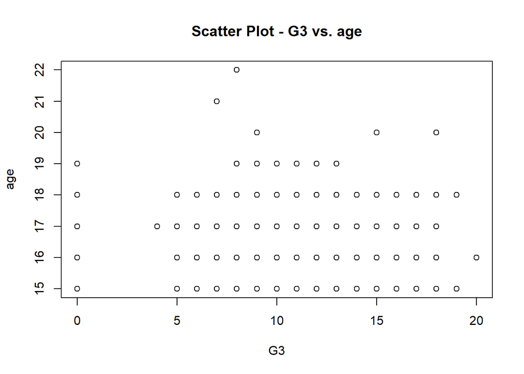

```
## [1] "Simple correlation check between the variables :  -0.16157943813834"
##
##  Kendall's rank correlation tau
##
## data:  df[, v] and df[, target_var]
## z = -3.4865, p-value = 0.0004893
## alternative hypothesis: true tau is not equal to 0
## sample estimates:
##        tau
## -0.1344711
##
## [1] "*************Medu*************"
```

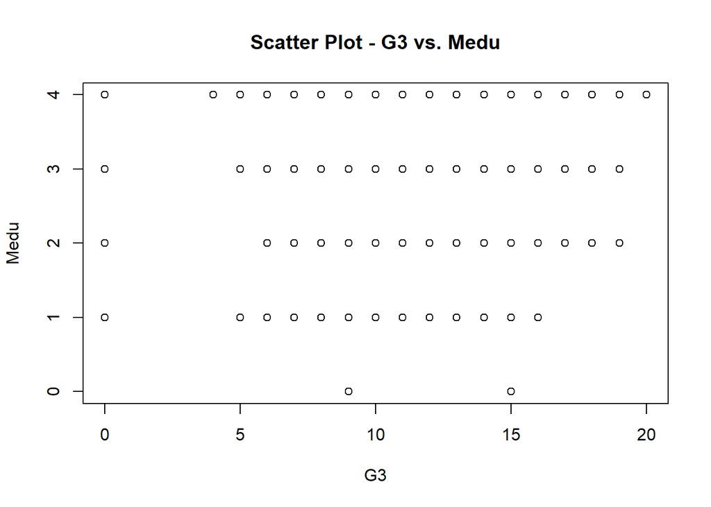

```
## [1] "Simple correlation check between the variables :  0.217147496138606"
##
##  Kendall's rank correlation tau
##
## data:  df[, v] and df[, target_var]
## z = 4.4578, p-value = 8.28e-06
## alternative hypothesis: true tau is not equal to 0
## sample estimates:
##       tau
## 0.1747663
##
## [1] "*************Fedu*************"
```

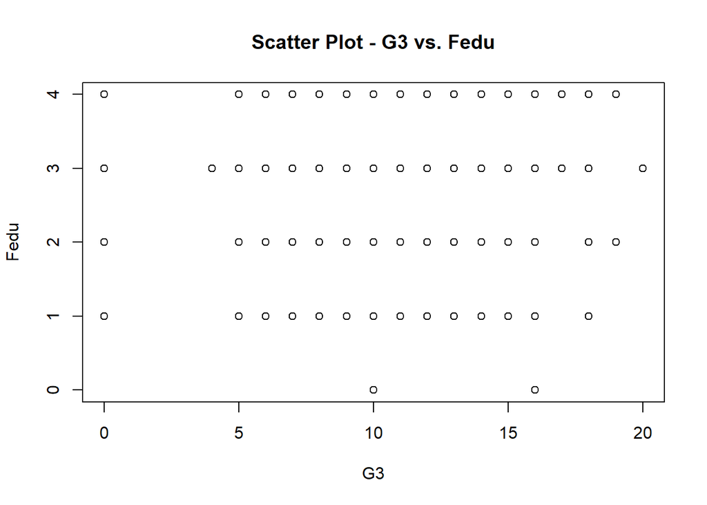

```
## [1] "Simple correlation check between the variables :  0.152456938904259"
##
##  Kendall's rank correlation tau
##
## data:  df[, v] and df[, target_var]
## z = 3.3884, p-value = 0.0007031
## alternative hypothesis: true tau is not equal to 0
## sample estimates:
##       tau
## 0.1324046
##
## [1] "*************traveltime*************"
```

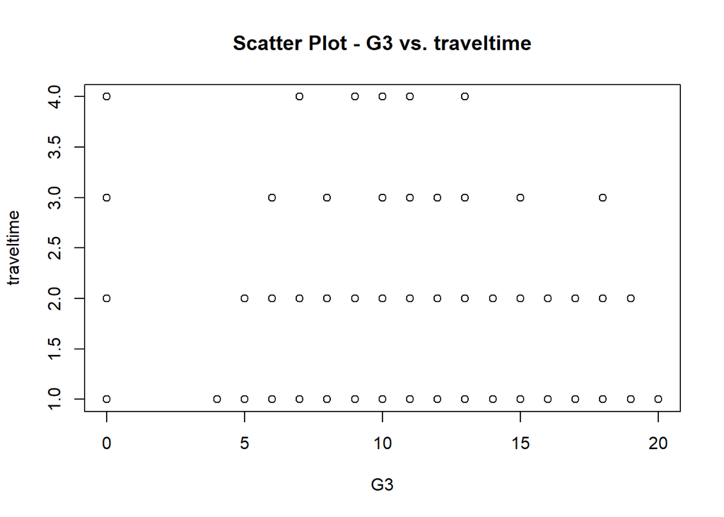

```
## [1] "Simple correlation check between the variables :  -0.117142052816149"
##
##  Kendall's rank correlation tau
##
## data:  df[, v] and df[, target_var]
## z = -2.3848, p-value = 0.01709
## alternative hypothesis: true tau is not equal to 0
## sample estimates:
##         tau
## -0.09899563
##
## [1] "*************studytime*************"
```

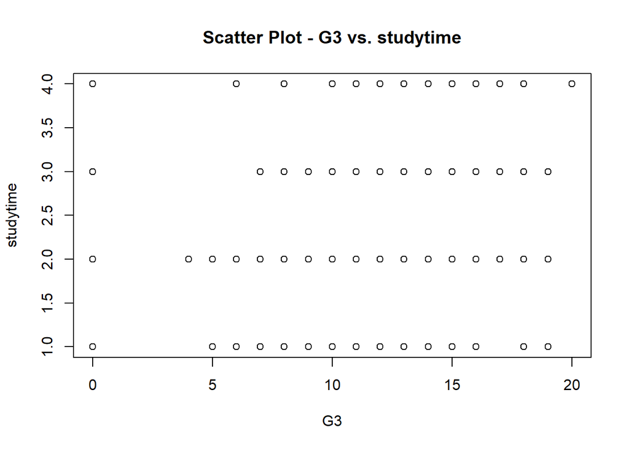

```
## [1] "Simple correlation check between the variables :  0.0978196896531963"
##
##  Kendall's rank correlation tau
##
## data:  df[, v] and df[, target_var]
## z = 2.1225, p-value = 0.03379
## alternative hypothesis: true tau is not equal to 0
## sample estimates:
##        tau
## 0.08511177
##
## [1] "*************failures*************"
```

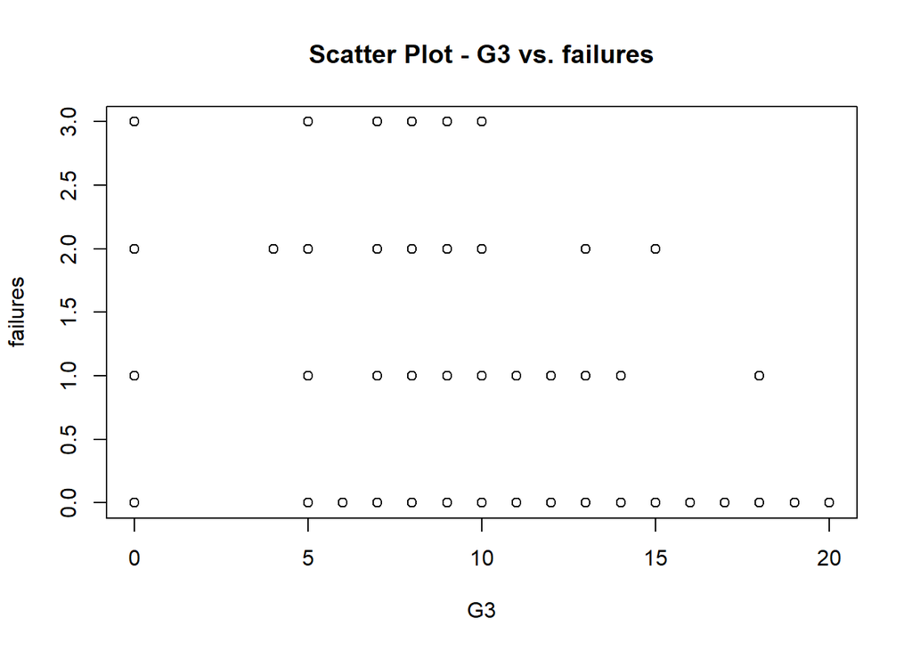

```
## [1] "Simple correlation check between the variables :  -0.36041494046165"
##
##  Kendall's rank correlation tau
##
## data:  df[, v] and df[, target_var]
## z = -7.1924, p-value = 6.366e-13
## alternative hypothesis: true tau is not equal to 0
## sample estimates:
##        tau
## -0.2991849
##
## [1] "*************famrel*************"
```

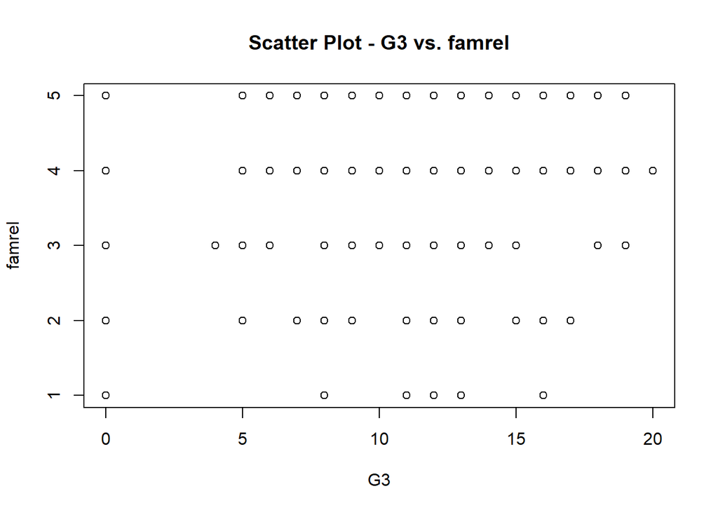

```
## [1] "Simple correlation check between the variables :  0.0513634288812822"
##
##  Kendall's rank correlation tau
##
## data:  df[, v] and df[, target_var]
## z = 1.0994, p-value = 0.2716
## alternative hypothesis: true tau is not equal to 0
## sample estimates:
##        tau
## 0.04400735
##
## [1] "*************freetime*************"
```

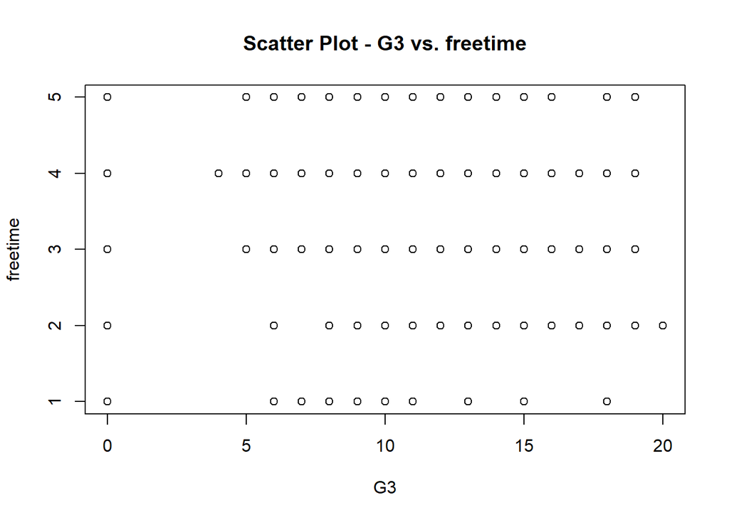

```
## [1] "Simple correlation check between the variables :  0.011307240308313"
##
##  Kendall's rank correlation tau
##
## data:  df[, v] and df[, target_var]
## z = -0.095352, p-value = 0.924
## alternative hypothesis: true tau is not equal to 0
## sample estimates:
##          tau
## -0.003745559
##
## [1] "*************goout*************"
```

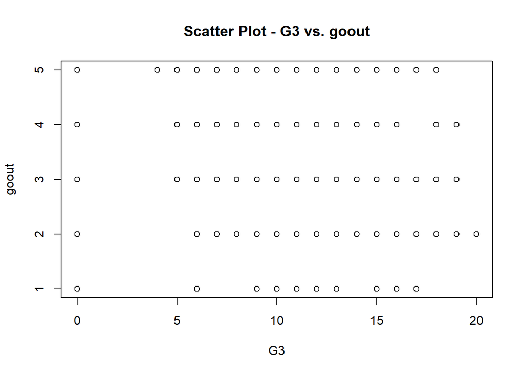

```
## [1] "Simple correlation check between the variables :  -0.132791473503329"
##
##  Kendall's rank correlation tau
##
## data:  df[, v] and df[, target_var]
## z = -3.3465, p-value = 0.0008183
## alternative hypothesis: true tau is not equal to 0
## sample estimates:
##        tau
## -0.1301101
##
## [1] "*************Dalc*************"
```

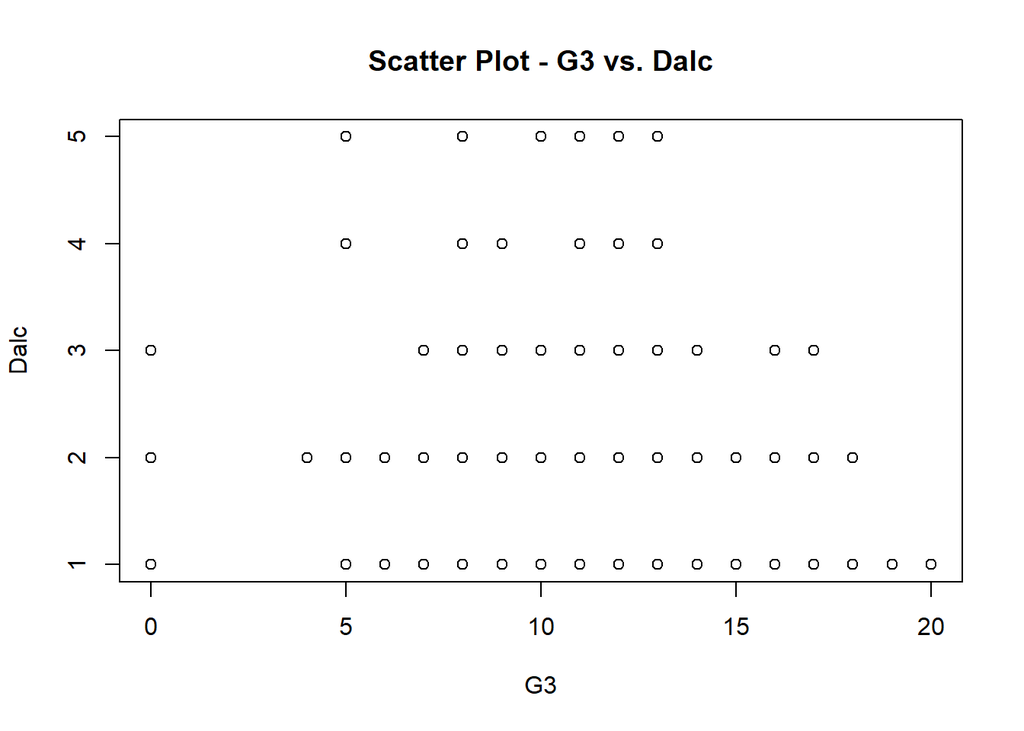

```
## [1] "Simple correlation check between the variables :  -0.0546600405667359"
##
##  Kendall's rank correlation tau
##
## data:  df[, v] and df[, target_var]
## z = -2.3613, p-value = 0.01821
## alternative hypothesis: true tau is not equal to 0
## sample estimates:
##         tau
## -0.09715354
##
## [1] "*************Walc*************"
```

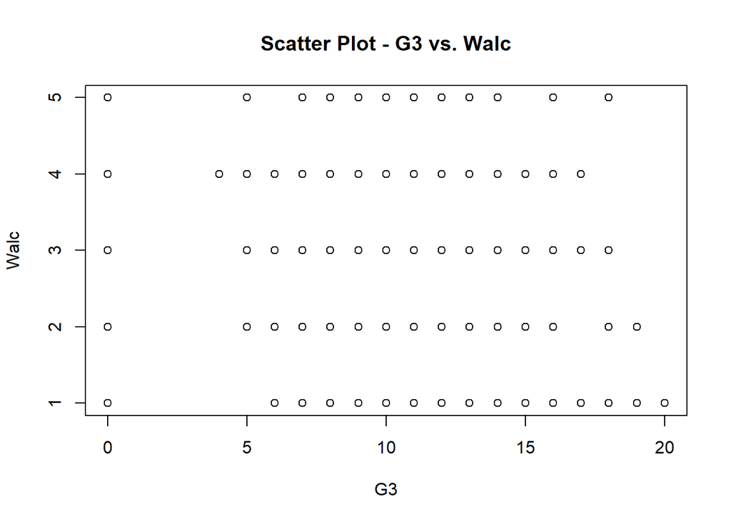

```
## [1] "Simple correlation check between the variables :  -0.0519393237422462"
##
##  Kendall's rank correlation tau
##
## data:  df[, v] and df[, target_var]
## z = -2.1282, p-value = 0.03332
## alternative hypothesis: true tau is not equal to 0
## sample estimates:
##         tau
## -0.08283759
##
## [1] "*************health*************"
```

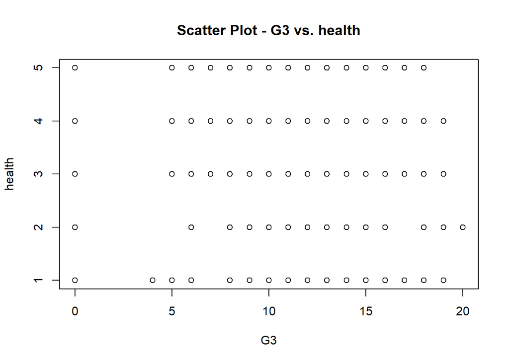

```
## [1] "Simple correlation check between the variables :  -0.0613346048771213"
##
##  Kendall's rank correlation tau
##
## data:  df[, v] and df[, target_var]
## z = -0.94436, p-value = 0.345
## alternative hypothesis: true tau is not equal to 0
## sample estimates:
##         tau
## -0.03662379
##
## [1] "*************absences*************"
```

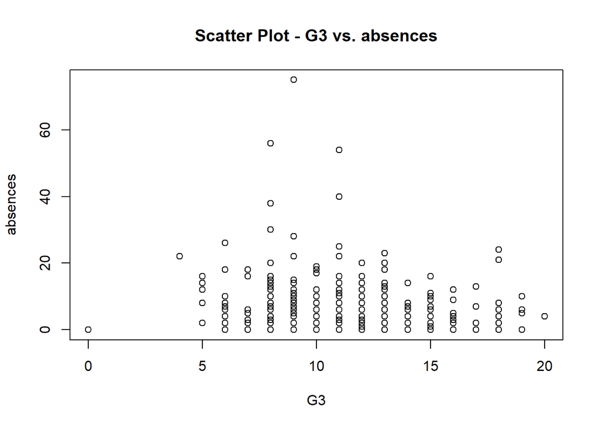

```
## [1] "Simple correlation check between the variables :  0.0342473161500693"
##
##  Kendall's rank correlation tau
##
## data:  df[, v] and df[, target_var]
## z = 0.1001, p-value = 0.9203
## alternative hypothesis: true tau is not equal to 0
## sample estimates:
##         tau
## 0.003722516
##
## [1] "*************G1*************"
```

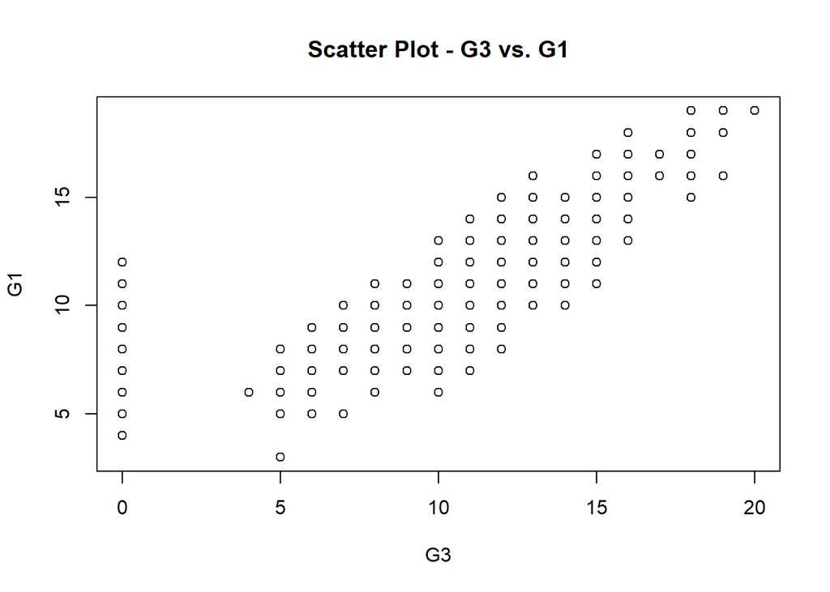

```
## [1] "Simple correlation check between the variables :  0.801467932017414"
##
##  Kendall's rank correlation tau
##
## data:  df[, v] and df[, target_var]
## z = 20.506, p-value < 2.2e-16
## alternative hypothesis: true tau is not equal to 0
## sample estimates:
##       tau
## 0.7463426
##
## [1] "*************G2*************"
```

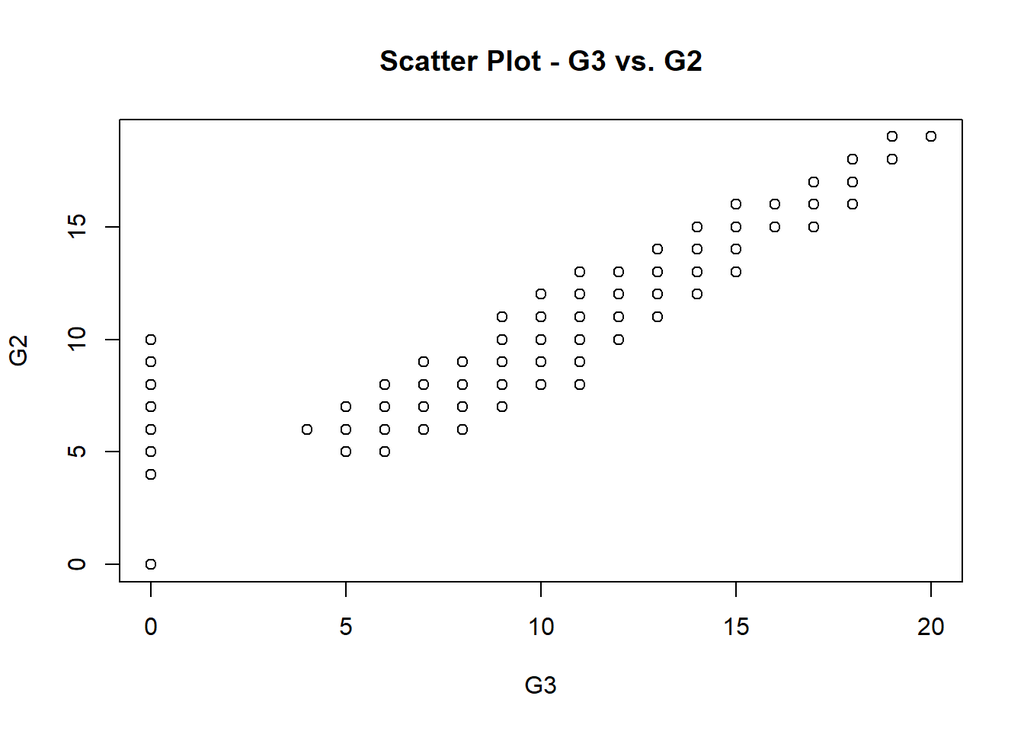

```
## [1] "Simple correlation check between the variables :  0.904867989269301"
##
##  Kendall's rank correlation tau
##
## data:  df[, v] and df[, target_var]
## z = 24.292, p-value < 2.2e-16
## alternative hypothesis: true tau is not equal to 0
## sample estimates:
##       tau
## 0.8835184
```

```r
assoc_fac_df <- diagnose_association_factor(df = student_mat_data,
                                            factor_vars = factor_cols,
                                            target_var = target_DV)
```

```
## [1] "-------------------- school --------------------"
## Unique values: GP, MS
```

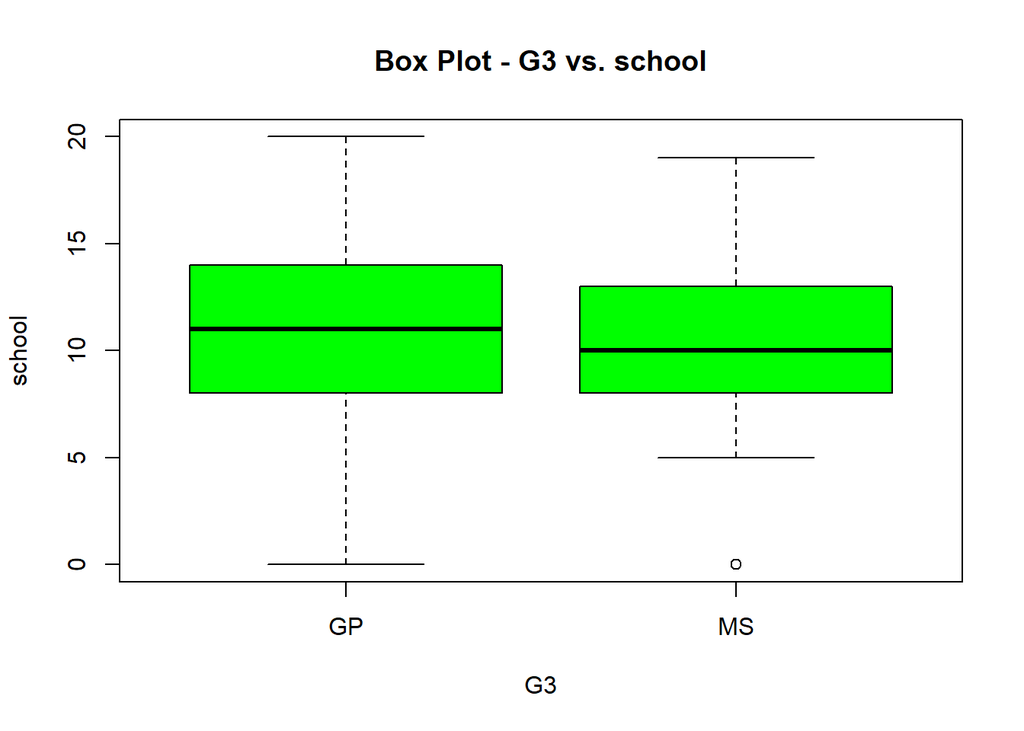

```
## [1] "-------------------- sex --------------------"
## Unique values: F, M
```

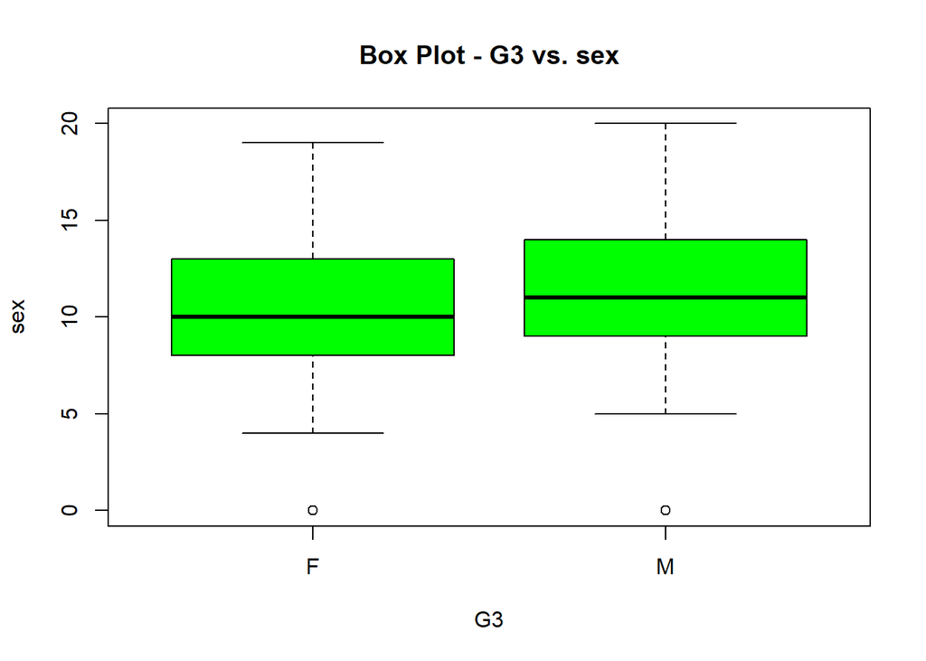

```
## [1] "-------------------- address --------------------"
## Unique values: U, R
```

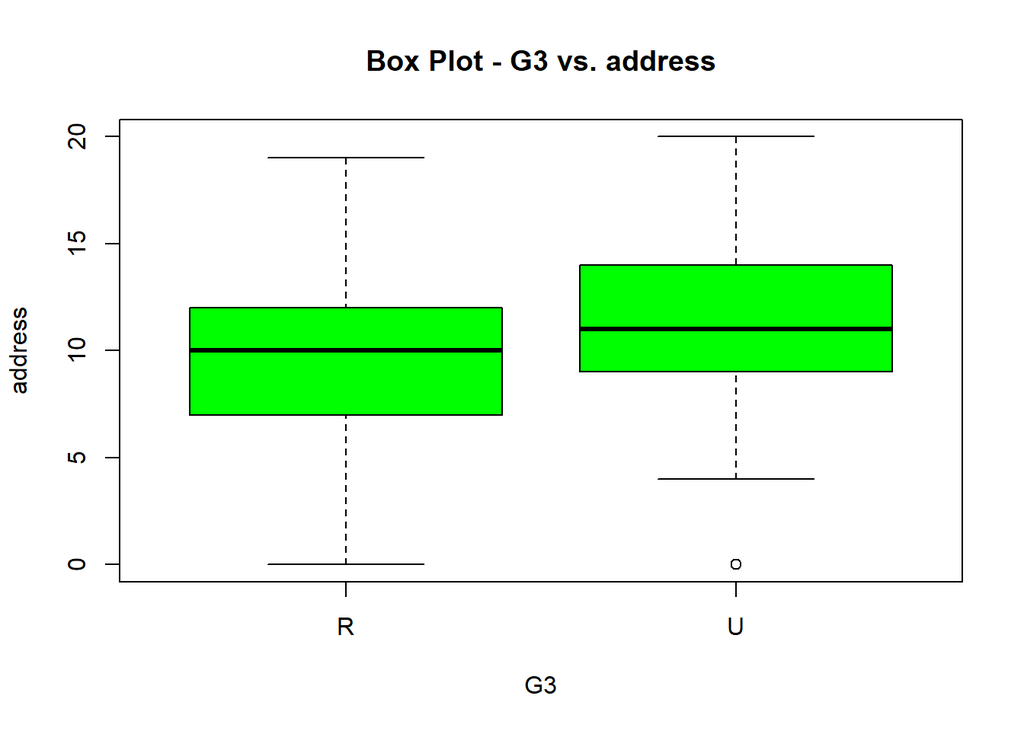

```
## [1] "-------------------- famsize --------------------"
## Unique values: GT3, LE3
```

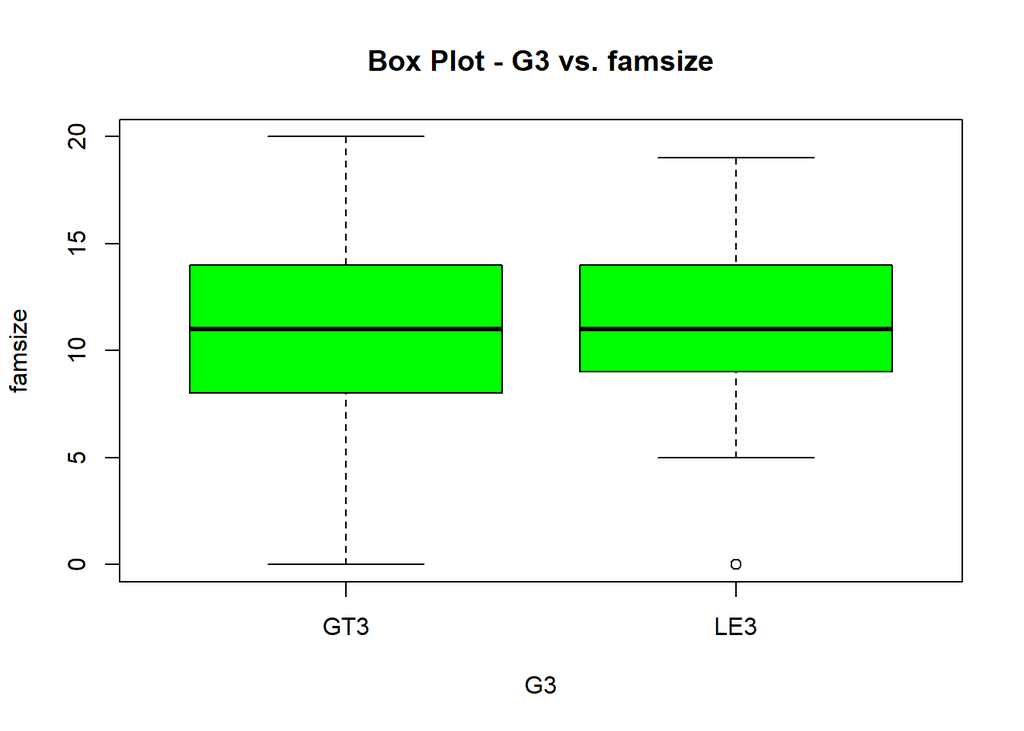

```
## [1] "-------------------- Pstatus --------------------"
## Unique values: A, T
```

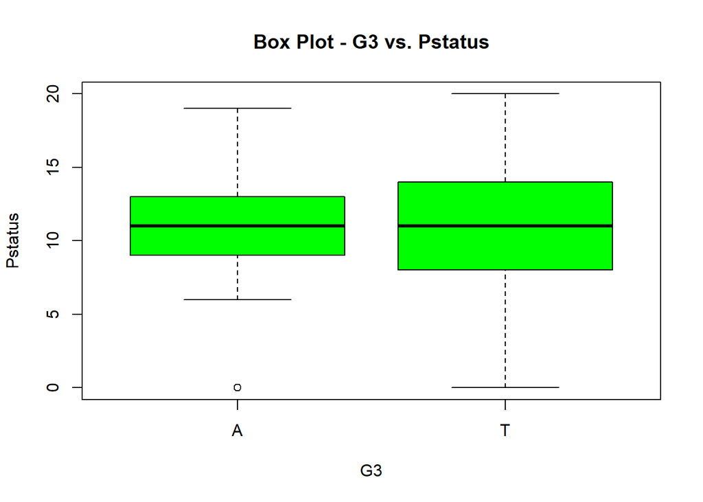

```
## [1] "-------------------- Mjob --------------------"
## Unique values: at_home, health, other, services, teacher
```

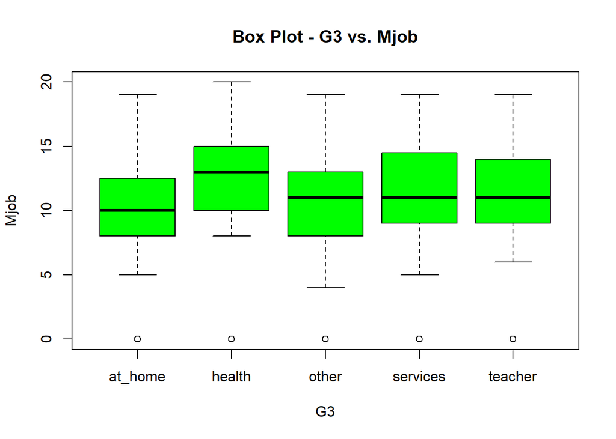

```
## [1] "-------------------- Fjob --------------------"
## Unique values: teacher, other, services, health, at_home
```

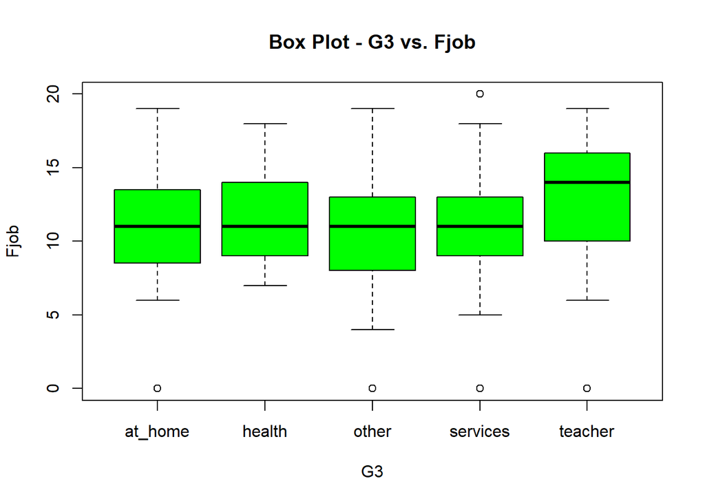

```
## [1] "-------------------- reason --------------------"
## Unique values: course, other, home, reputation
```

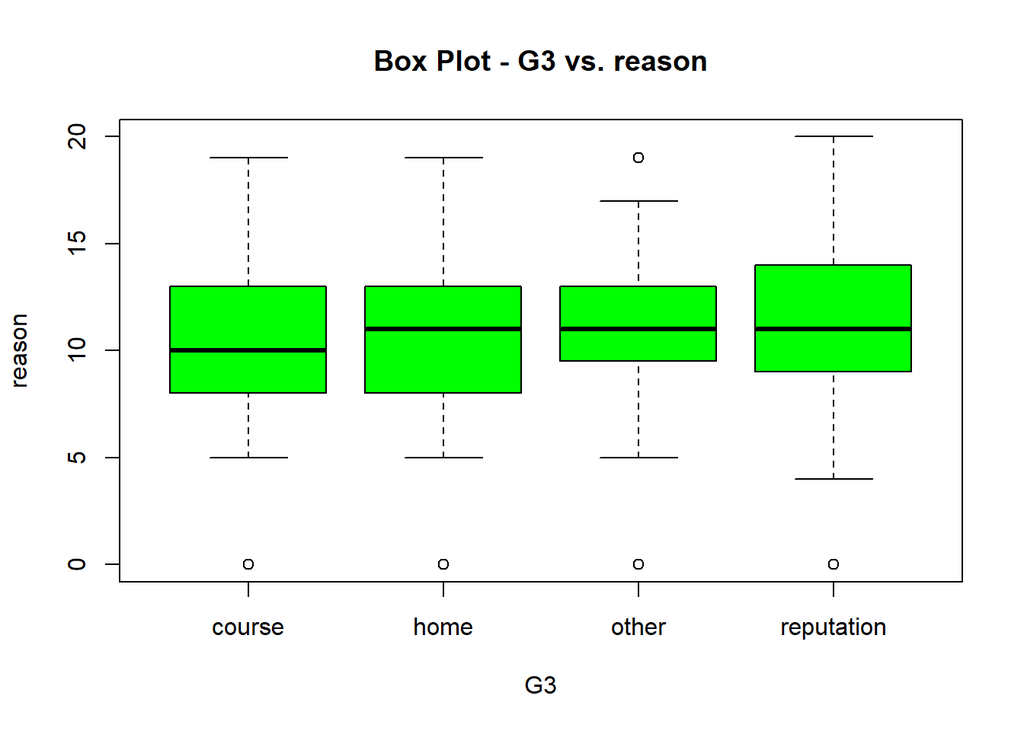

```
## [1] "-------------------- guardian --------------------"
## Unique values: mother, father, other
```

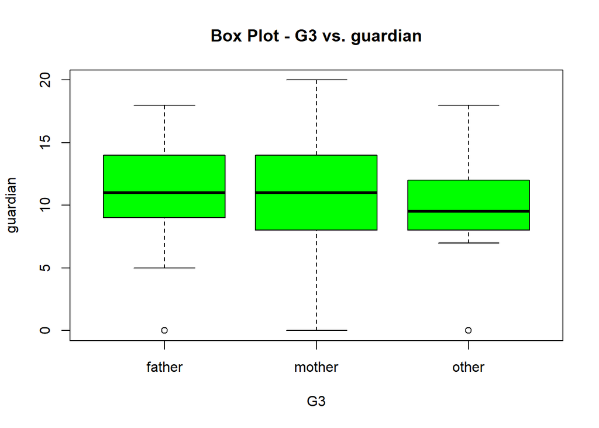

```
## [1] "-------------------- schoolsup --------------------"
## Unique values: yes, no
```

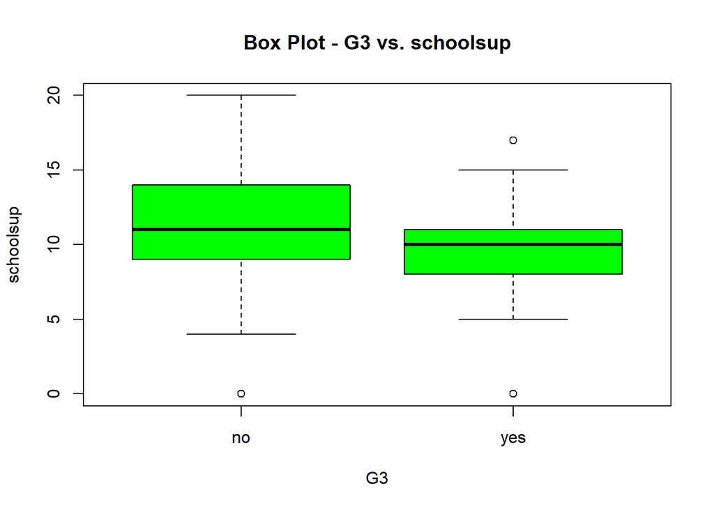

```
## [1] "-------------------- famsup --------------------"
## Unique values: no, yes
```

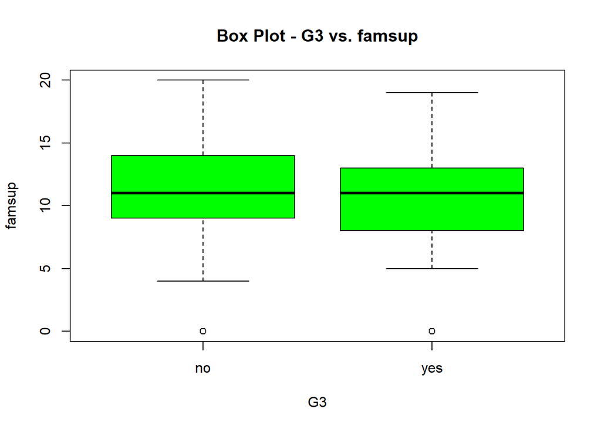

```
## [1] "-------------------- paid --------------------"
## Unique values: no, yes
```

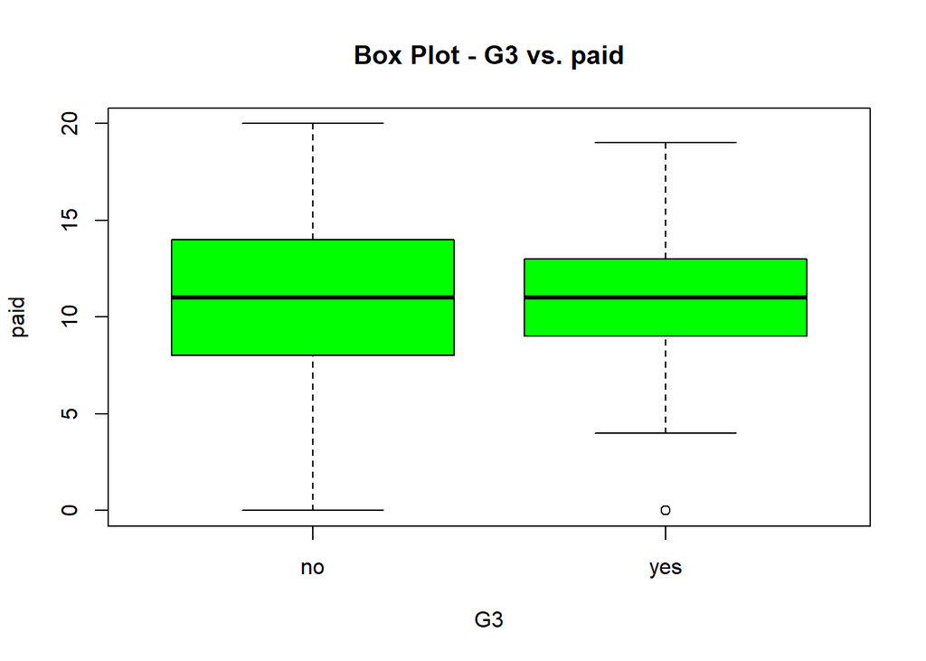

```
## [1] "-------------------- activities --------------------"
## Unique values: no, yes
```

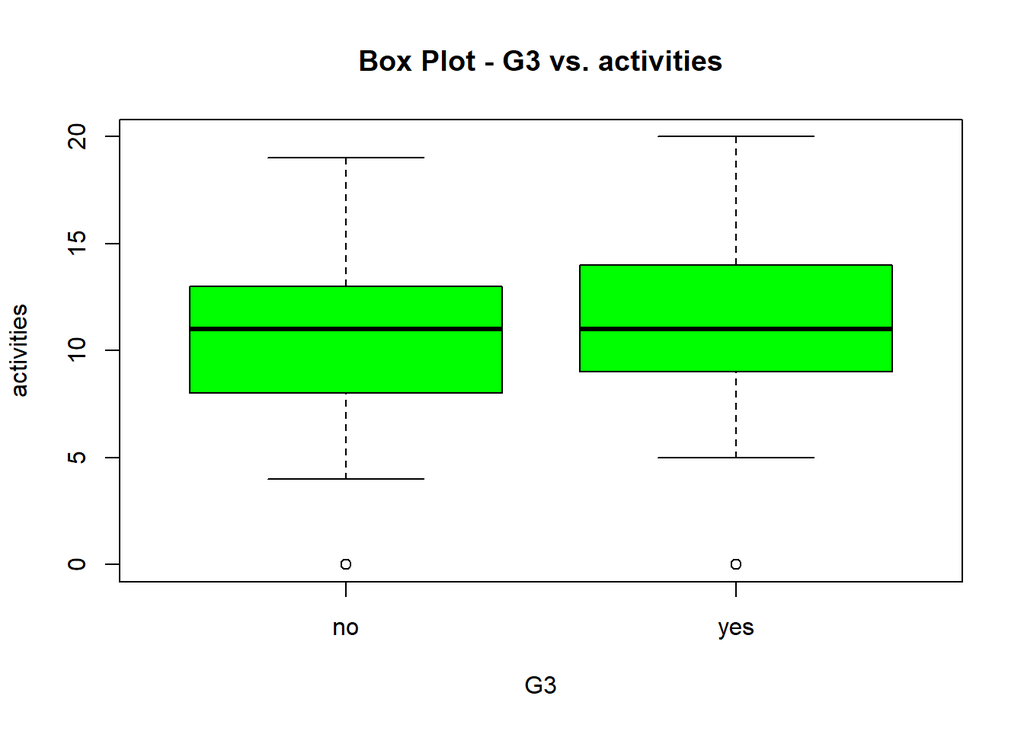

```
## [1] "-------------------- nursery --------------------"
## Unique values: yes, no
```

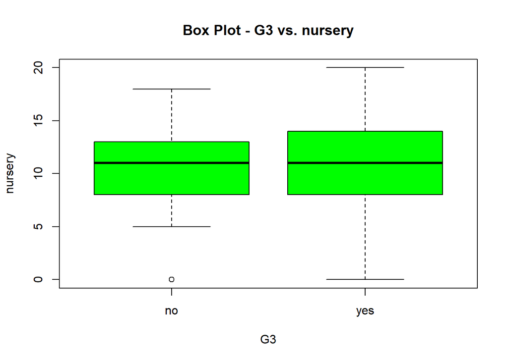

```
## [1] "-------------------- higher --------------------"
## Unique values: yes, no
```

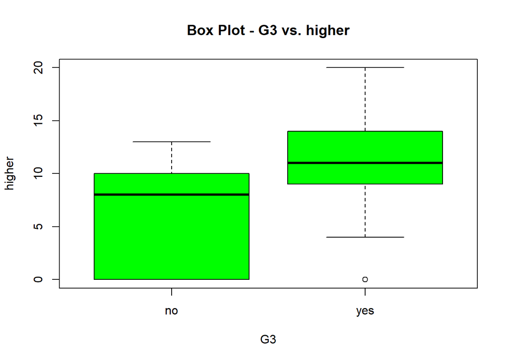

```
## [1] "-------------------- internet --------------------"
## Unique values: no, yes
```

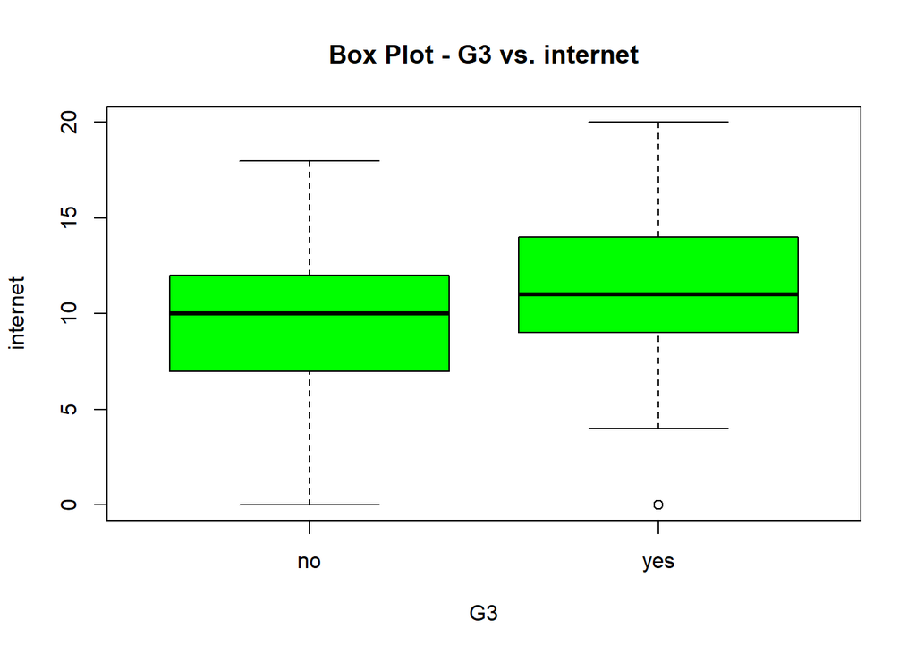

```
## [1] "-------------------- romantic --------------------"
## Unique values: no, yes
```

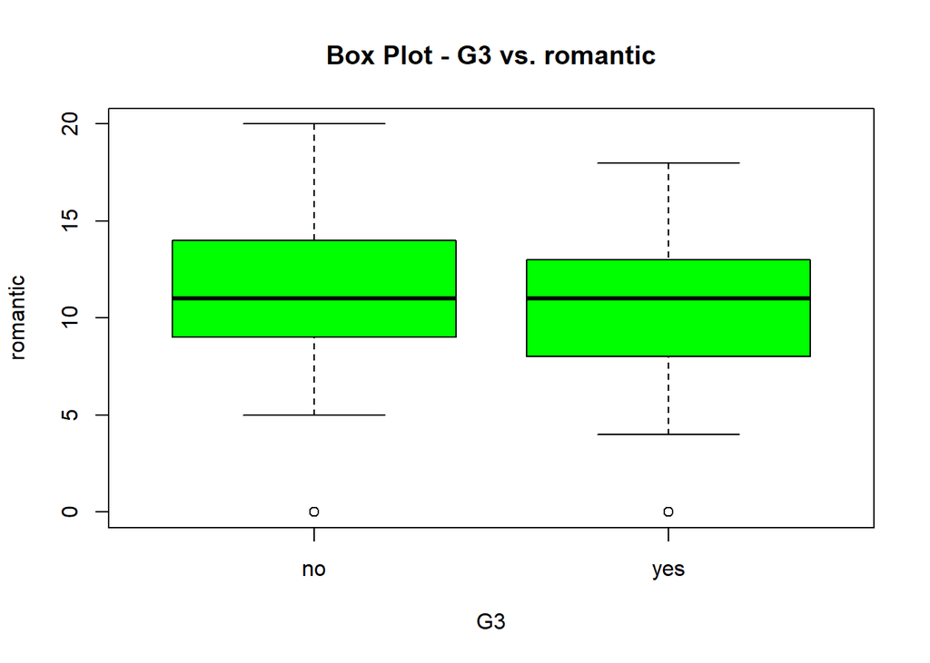

```r
qualified_features_data <- assoc_num_df %>% rbind.data.frame(assoc_fac_df)

# CHATGPT: how to sort a dataframe in R?
qualified_features_data[order(qualified_features_data$result, decreasing = FALSE), ]
```

```
##    feature1   feature2       p.value test_employed signif result
## 7        G3     famrel  2.716000e-01       kendall   0.05   fail
## 8        G3   freetime  9.240350e-01       kendall   0.05   fail
## 12       G3     health  3.449856e-01       kendall   0.05   fail
## 13       G3   absences  9.202645e-01       kendall   0.05   fail
## 16       G3     school  3.431317e-01      two.test   0.05   fail
## 19       G3    famsize  9.155471e-02      two.test   0.05   fail
## 20       G3    Pstatus  2.281647e-01      two.test   0.05   fail
## 22       G3       Fjob  2.771176e-01         anova   0.05   fail
## 23       G3     reason  9.179666e-02         anova   0.05   fail
## 24       G3   guardian  2.258658e-01         anova   0.05   fail
## 26       G3     famsup  4.397524e-01      two.test   0.05   fail
## 28       G3 activities  7.495605e-01      two.test   0.05   fail
## 29       G3    nursery  3.063540e-01      two.test   0.05   fail
## 1        G3        age  4.893167e-04       kendall   0.05   pass
```

[output cut: 18 more lines]

The features seen in the above dataframe tthat has failed in the association test have no association. I thought of discarding them, but will let the models decide.

###### c. Draw a histogram of the target variable “G3” and interpret it.

Let us draw the histogram understand the distribution.

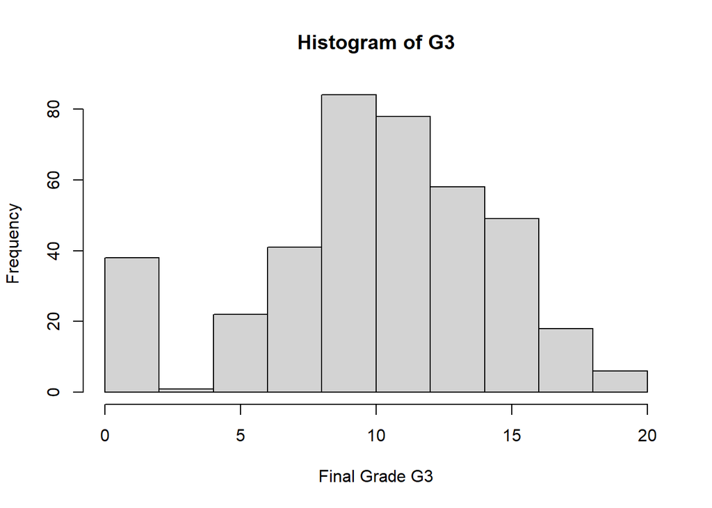

```r
# Historgram of Target DV - G3
hist(student_mat_data$G3, main = "Histogram of G3", xlab = "Final Grade G3", ylab = "Frequency")
```

```r
print(paste("Mean of G3: ",mean(student_mat_data$G3)))
```

```
## [1] "Mean of G3:  10.4151898734177"
```

```r
print(paste("MeDdian of G3: ",median(student_mat_data$G3)))
```

```
## [1] "MeDdian of G3:  11"
```

#### 13. (0.5 pt) Split the data into train and test. Use 80% of samples for training and 20% of samples for testing.

```r
# CHATGPT: how to split dataframe into train and test

# Although the lecutre notes show splitting datasets iusing the sample function
# I still wanted to check with CHAT GPT for some other functions and ways
# I found out about caTools and other ways, train and test split used CHat CPT and I just included necessary variables

# Setting the seed for reproducibility
set.seed(123)
split_perc <- 0.8
indices <- sample(nrow(student_mat_data))
train_size <- round(split_perc * nrow(student_mat_data))

# Finding the train indices
train_indices <- indices[1:train_size]

# Create train and test dataframes
student_mat_data_train <- student_mat_data[train_indices, ]
student_mat_data_test <- student_mat_data[-train_indices, ]
```

#### 14. set the random seed: set.seed(123)

That is already set, yet doing it one more time.

```r
set.seed(123)
```

#### 15. (2 pt) Use caret package to run 10 fold cross validation using linear regression method on the train data to predict the “G3” variable . Print the resulting model to see the cross validation RMSE. In addition, take a summary of the model and interpret the coefficients. Which coefficients are statistically different from zero? What does this mean?

I am gonna reuse the code from the lecture notes.

```r
# cv Technique on train data
train.control = trainControl(method = "cv", number = 10)
model = train(G3~., data = student_mat_data_train, method = "lm", trControl = train.control)
```

Let us print the model and understand the model performance and coefficients.

```r
# Checking the model
print(model)
```

```
## Linear Regression
##
## 316 samples
##  32 predictor
##
## No pre-processing
## Resampling: Cross-Validated (10 fold)
## Summary of sample sizes: 284, 284, 284, 285, 284, 285, ...
## Resampling results:
##
##   RMSE      Rsquared   MAE
##   1.882724  0.8376777  1.290976
##
## Tuning parameter 'intercept' was held constant at a value of TRUE
```

```r
summary(model)
```

```
##
## Call:
## lm(formula = .outcome ~ ., data = dat)
##
## Residuals:
##     Min      1Q  Median      3Q     Max
## -7.7950 -0.5700  0.2317  0.9342  3.6128
##
## Coefficients:
##                  Estimate Std. Error t value Pr(>|t|)
## (Intercept)       0.46394    2.25554   0.206  0.83719
## schoolMS          0.36709    0.39153   0.938  0.34928
## sexM              0.16857    0.24790   0.680  0.49707
## age              -0.27251    0.10696  -2.548  0.01139 *
## addressU         -0.05133    0.28210  -0.182  0.85576
## famsizeLE3        0.14287    0.23575   0.606  0.54500
## PstatusT          0.41128    0.36366   1.131  0.25906
## Medu              0.28791    0.15838   1.818  0.07017 .
## Fedu             -0.09785    0.13212  -0.741  0.45953
## Mjobhealth       -0.31866    0.53209  -0.599  0.54975
## Mjobother         0.21437    0.34940   0.614  0.54002
## Mjobservices     -0.03949    0.38471  -0.103  0.91831
## Mjobteacher      -0.19449    0.50958  -0.382  0.70300
## Fjobhealth        0.03555    0.68119   0.052  0.95842
## Fjobother        -0.25423    0.50033  -0.508  0.61177
## Fjobservices     -0.65872    0.51688  -1.274  0.20360
## Fjobteacher      -0.15668    0.63228  -0.248  0.80448
## reasonhome       -0.13167    0.27229  -0.484  0.62909
## reasonother       0.18999    0.39686   0.479  0.63251
## reasonreputation  0.18665    0.27684   0.674  0.50074
## guardianmother    0.13251    0.26165   0.506  0.61296
## guardianother    -0.03277    0.50416  -0.065  0.94822
## traveltime       -0.02286    0.16926  -0.135  0.89266
## studytime        -0.12663    0.14223  -0.890  0.37408
## failures         -0.30228    0.18728  -1.614  0.10768
## schoolsupyes      0.12423    0.35474   0.350  0.72647
## famsupyes         0.29488    0.23845   1.237  0.21726
## paidyes           0.10148    0.23503   0.432  0.66622
## activitiesyes    -0.45009    0.21633  -2.081  0.03840 *
## nurseryyes       -0.38983    0.26694  -1.460  0.14534
## higheryes         0.24008    0.57492   0.418  0.67658
## internetyes      -0.14989    0.30852  -0.486  0.62748
## romanticyes      -0.25115    0.22892  -1.097  0.27355
## famrel            0.33899    0.11983   2.829  0.00502 **
## freetime         -0.01242    0.11462  -0.108  0.91377
## goout             0.07900    0.11263   0.701  0.48365
## Dalc             -0.18520    0.16094  -1.151  0.25084
## Walc              0.11346    0.12277   0.924  0.35622
## health            0.10790    0.07775   1.388  0.16631
## absences          0.04563    0.01388   3.286  0.00115 **
## G1                0.14700    0.06549   2.244  0.02561 *
## G2                0.98676    0.05622  17.553  < 2e-16 ***
## ---
## Signif. codes:  0 '***' 0.001 '**' 0.01 '*' 0.05 '.' 0.1 ' ' 1
##
## Residual standard error: 1.766 on 274 degrees of freedom
## Multiple R-squared:  0.866,  Adjusted R-squared:  0.8459
## F-statistic: 43.19 on 41 and 274 DF,  p-value: < 2.2e-16
```

Ideally residual meadn should be 0, ours is close to 0; t value - how true coeffs are significantly different from 0. P value - is the tru coeff significantly diffrent from 0. Statistically signficant features - G2, G1, absences, famrel, activitieiesyes, age are very much significant feature statistically, escpecially G2; When we see the R SQ values, we can undesrtatnd the regression line very well fits the data points.

#### Set the random seed again. We need to do this before each training to ensure we get the same folds in cross validation. Set.seed(123) so we can compare the models using their cross validation RMSE.(2 pts) Use caret and leap packages to run a 10 fold cross validation using step wise linear regression method with backward selection on the train data. The train method by default uses maximum of 4 predictors and reports the best models with 1..4 predictors. We need to change this parameter to consider all predictors. So inside your train function, add the following parameter tuneGrid = data.frame(nvmax = 1:n), where n is the number of variables you use to predict “G3”.

I am gonna reuse the codes from the lecture.

```r
# Setting seed, althought I have set it in the previous R code chunks
set.seed(123)

# Stepwise regression
# Backwards eliminiation

number_of_predictors <- ncol(student_mat_data_train) - 1

train.control <- trainControl(method = "cv", number = 10)
tune.grid <- data.frame(nvmax = c(1 : number_of_predictors))
# tune.grid <- data.frame(nvmax = c(4 : number_of_predictors))
wrapper_method = "leapBackward"

step.model <- train(G3 ~.,
                    data = student_mat_data_train,
                    method = wrapper_method,
                    tuneGrid = tune.grid,
                    trControl = train.control
                    )

# Checking the model
print(step.model)
```

```
## Linear Regression with Backwards Selection
##
## 316 samples
##  32 predictor
##
## No pre-processing
## Resampling: Cross-Validated (10 fold)
## Summary of sample sizes: 284, 284, 284, 285, 284, 285, ...
## Resampling results across tuning parameters:
##
##   nvmax  RMSE      Rsquared   MAE
##    1     1.730845  0.8599512  1.049833
##    2     1.792013  0.8473356  1.107033
##    3     1.799260  0.8465628  1.138853
##    4     1.786277  0.8495669  1.162251
```

[output cut: 31 more lines]

```r
summary(step.model)
```

```
## Subset selection object
## 41 Variables  (and intercept)
##                  Forced in Forced out
## schoolMS             FALSE      FALSE
## sexM                 FALSE      FALSE
## age                  FALSE      FALSE
## addressU             FALSE      FALSE
## famsizeLE3           FALSE      FALSE
## PstatusT             FALSE      FALSE
## Medu                 FALSE      FALSE
## Fedu                 FALSE      FALSE
## Mjobhealth           FALSE      FALSE
## Mjobother            FALSE      FALSE
## Mjobservices         FALSE      FALSE
## Mjobteacher          FALSE      FALSE
## Fjobhealth           FALSE      FALSE
## Fjobother            FALSE      FALSE
## Fjobservices         FALSE      FALSE
## Fjobteacher          FALSE      FALSE
## reasonhome           FALSE      FALSE
## reasonother          FALSE      FALSE
## reasonreputation     FALSE      FALSE
## guardianmother       FALSE      FALSE
## guardianother        FALSE      FALSE
## traveltime           FALSE      FALSE
## studytime            FALSE      FALSE
## failures             FALSE      FALSE
## schoolsupyes         FALSE      FALSE
## famsupyes            FALSE      FALSE
## paidyes              FALSE      FALSE
## activitiesyes        FALSE      FALSE
## nurseryyes           FALSE      FALSE
## higheryes            FALSE      FALSE
## internetyes          FALSE      FALSE
## romanticyes          FALSE      FALSE
## famrel               FALSE      FALSE
## freetime             FALSE      FALSE
## goout                FALSE      FALSE
## Dalc                 FALSE      FALSE
## Walc                 FALSE      FALSE
## health               FALSE      FALSE
## absences             FALSE      FALSE
## G1                   FALSE      FALSE
## G2                   FALSE      FALSE
## 1 subsets of each size up to 1
## Selection Algorithm: backward
##          schoolMS sexM age addressU famsizeLE3 PstatusT Medu Fedu Mjobhealth
## 1  ( 1 ) " "      " "  " " " "      " "        " "      " "  " "  " "
##          Mjobother Mjobservices Mjobteacher Fjobhealth Fjobother Fjobservices
## 1  ( 1 ) " "       " "          " "         " "        " "       " "
##          Fjobteacher reasonhome reasonother reasonreputation guardianmother
## 1  ( 1 ) " "         " "        " "         " "              " "
##          guardianother traveltime studytime failures schoolsupyes famsupyes
## 1  ( 1 ) " "           " "        " "       " "      " "          " "
##          paidyes activitiesyes nurseryyes higheryes internetyes romanticyes
## 1  ( 1 ) " "     " "           " "        " "       " "         " "
##          famrel freetime goout Dalc Walc health absences G1  G2
## 1  ( 1 ) " "    " "      " "   " "  " "  " "    " "      " " "*"
```

```r
summary(step.model$finalModel)
```

```
## Subset selection object
## 41 Variables  (and intercept)
##                  Forced in Forced out
## schoolMS             FALSE      FALSE
## sexM                 FALSE      FALSE
## age                  FALSE      FALSE
## addressU             FALSE      FALSE
## famsizeLE3           FALSE      FALSE
## PstatusT             FALSE      FALSE
## Medu                 FALSE      FALSE
## Fedu                 FALSE      FALSE
## Mjobhealth           FALSE      FALSE
## Mjobother            FALSE      FALSE
## Mjobservices         FALSE      FALSE
## Mjobteacher          FALSE      FALSE
## Fjobhealth           FALSE      FALSE
## Fjobother            FALSE      FALSE
## Fjobservices         FALSE      FALSE
## Fjobteacher          FALSE      FALSE
## reasonhome           FALSE      FALSE
## reasonother          FALSE      FALSE
## reasonreputation     FALSE      FALSE
## guardianmother       FALSE      FALSE
## guardianother        FALSE      FALSE
## traveltime           FALSE      FALSE
## studytime            FALSE      FALSE
## failures             FALSE      FALSE
## schoolsupyes         FALSE      FALSE
## famsupyes            FALSE      FALSE
## paidyes              FALSE      FALSE
## activitiesyes        FALSE      FALSE
## nurseryyes           FALSE      FALSE
## higheryes            FALSE      FALSE
## internetyes          FALSE      FALSE
## romanticyes          FALSE      FALSE
## famrel               FALSE      FALSE
## freetime             FALSE      FALSE
## goout                FALSE      FALSE
## Dalc                 FALSE      FALSE
## Walc                 FALSE      FALSE
## health               FALSE      FALSE
## absences             FALSE      FALSE
## G1                   FALSE      FALSE
## G2                   FALSE      FALSE
## 1 subsets of each size up to 1
## Selection Algorithm: backward
##          schoolMS sexM age addressU famsizeLE3 PstatusT Medu Fedu Mjobhealth
## 1  ( 1 ) " "      " "  " " " "      " "        " "      " "  " "  " "
##          Mjobother Mjobservices Mjobteacher Fjobhealth Fjobother Fjobservices
## 1  ( 1 ) " "       " "          " "         " "        " "       " "
##          Fjobteacher reasonhome reasonother reasonreputation guardianmother
## 1  ( 1 ) " "         " "        " "         " "              " "
##          guardianother traveltime studytime failures schoolsupyes famsupyes
## 1  ( 1 ) " "           " "        " "       " "      " "          " "
##          paidyes activitiesyes nurseryyes higheryes internetyes romanticyes
## 1  ( 1 ) " "     " "           " "        " "       " "         " "
##          famrel freetime goout Dalc Walc health absences G1  G2
## 1  ( 1 ) " "    " "      " "   " "  " "  " "    " "      " " "*"
```

```r
# Coefficient names and values
coef_names <- names(coef(step.model$finalModel, id = step.model$bestTune$nvmax[1]))
coef_values <- coef(step.model$finalModel, id = step.model$bestTune$nvmax[1])

# Performance metrics
rmse <- step.model$results$RMSE

# Create dataframe
model_summary <- data.frame(
  Coefficient_Names = coef_names,
  Coefficient_Values = coef_values
)

# Print the dataframe
print(model_summary)
```

```
##             Coefficient_Names Coefficient_Values
## (Intercept)       (Intercept)          -1.354208
## G2                         G2           1.102498
```

```r
print(paste("Number of variables - best tune : ", step.model$bestTune$nvmax[1]))
```

```
## [1] "Number of variables - best tune :  1"
```

```r
print(rmse)
```

```
##  [1] 1.730845 1.792013 1.799260 1.786277 1.768879 1.769357 1.744032 1.735027
##  [9] 1.753592 1.778479 1.793311 1.801177 1.815321 1.822343 1.810685 1.812505
## [17] 1.819875 1.832588 1.832585 1.842643 1.847791 1.851610 1.854094 1.865739
## [25] 1.867027 1.874593 1.873470 1.875226 1.877458 1.874904 1.878859 1.881413
```

Equation becomes : G3 = -1.354208 + 1.102498 * G2

Let us check the model and its summary. From the summary we see that the backward selection has chosen only one variable. And the model performnace is given below.

nvmax RMSE Rsquared MAE  
1 1.730845 0.8599512 1.049833

*TESTING LEAFFORWARD*

just testing

```r
number_of_predictors2 <- ncol(student_mat_data_train) - 1

train.control2 <- trainControl(method = "cv", number = 10)
tune.grid2 <- data.frame(nvmax = c(2 : number_of_predictors))
wrapper_method2 = "leapForward"

step.model2 <- train(G3 ~.,
                    data = student_mat_data_train,
                    method = wrapper_method2,
                    tuneGrid = tune.grid2,
                    trControl = train.control2
                    )

print(step.model2)
```

```
## Linear Regression with Forward Selection
##
## 316 samples
##  32 predictor
##
## No pre-processing
## Resampling: Cross-Validated (10 fold)
## Summary of sample sizes: 285, 285, 285, 284, 284, 284, ...
## Resampling results across tuning parameters:
##
##   nvmax  RMSE      Rsquared   MAE
##    2     1.815329  0.8380842  1.080634
##    3     1.809278  0.8387361  1.105851
##    4     1.826200  0.8358853  1.127044
##    5     1.782802  0.8447872  1.131371
```

[output cut: 30 more lines]

```r
summary(step.model2)
```

```
## Subset selection object
## 41 Variables  (and intercept)
##                  Forced in Forced out
## schoolMS             FALSE      FALSE
## sexM                 FALSE      FALSE
## age                  FALSE      FALSE
## addressU             FALSE      FALSE
## famsizeLE3           FALSE      FALSE
## PstatusT             FALSE      FALSE
## Medu                 FALSE      FALSE
## Fedu                 FALSE      FALSE
## Mjobhealth           FALSE      FALSE
## Mjobother            FALSE      FALSE
## Mjobservices         FALSE      FALSE
## Mjobteacher          FALSE      FALSE
## Fjobhealth           FALSE      FALSE
## Fjobother            FALSE      FALSE
## Fjobservices         FALSE      FALSE
## Fjobteacher          FALSE      FALSE
## reasonhome           FALSE      FALSE
## reasonother          FALSE      FALSE
## reasonreputation     FALSE      FALSE
## guardianmother       FALSE      FALSE
## guardianother        FALSE      FALSE
## traveltime           FALSE      FALSE
## studytime            FALSE      FALSE
## failures             FALSE      FALSE
## schoolsupyes         FALSE      FALSE
## famsupyes            FALSE      FALSE
## paidyes              FALSE      FALSE
## activitiesyes        FALSE      FALSE
## nurseryyes           FALSE      FALSE
## higheryes            FALSE      FALSE
## internetyes          FALSE      FALSE
## romanticyes          FALSE      FALSE
## famrel               FALSE      FALSE
## freetime             FALSE      FALSE
## goout                FALSE      FALSE
## Dalc                 FALSE      FALSE
## Walc                 FALSE      FALSE
```

[output cut: 45 more lines]

```
## 3  ( 1 ) " "     " "           " "        " "       " "         " "
## 4  ( 1 ) " "     " "           " "        " "       " "         " "
## 5  ( 1 ) " "     " "           " "        " "       " "         " "
## 6  ( 1 ) " "     " "           " "        " "       " "         " "
## 7  ( 1 ) " "     " "           " "        " "       " "         " "
## 8  ( 1 ) " "     "*"           " "        " "       " "         " "
##          famrel freetime goout Dalc Walc health absences G1  G2
## 1  ( 1 ) " "    " "      " "   " "  " "  " "    " "      " " "*"
## 2  ( 1 ) " "    " "      " "   " "  " "  " "    " "      " " "*"
## 3  ( 1 ) "*"    " "      " "   " "  " "  " "    " "      " " "*"
## 4  ( 1 ) "*"    " "      " "   " "  " "  " "    " "      " " "*"
## 5  ( 1 ) "*"    " "      " "   " "  " "  " "    "*"      " " "*"
## 6  ( 1 ) "*"    " "      " "   " "  " "  " "    "*"      " " "*"
## 7  ( 1 ) "*"    " "      " "   " "  " "  " "    "*"      "*" "*"
## 8  ( 1 ) "*"    " "      " "   " "  " "  " "    "*"      "*" "*"
```

```r
summary(step.model2$finalModel)
```

```
## Subset selection object
## 41 Variables  (and intercept)
##                  Forced in Forced out
## schoolMS             FALSE      FALSE
## sexM                 FALSE      FALSE
## age                  FALSE      FALSE
## addressU             FALSE      FALSE
## famsizeLE3           FALSE      FALSE
## PstatusT             FALSE      FALSE
## Medu                 FALSE      FALSE
## Fedu                 FALSE      FALSE
## Mjobhealth           FALSE      FALSE
## Mjobother            FALSE      FALSE
## Mjobservices         FALSE      FALSE
## Mjobteacher          FALSE      FALSE
## Fjobhealth           FALSE      FALSE
## Fjobother            FALSE      FALSE
## Fjobservices         FALSE      FALSE
## Fjobteacher          FALSE      FALSE
## reasonhome           FALSE      FALSE
## reasonother          FALSE      FALSE
## reasonreputation     FALSE      FALSE
## guardianmother       FALSE      FALSE
## guardianother        FALSE      FALSE
## traveltime           FALSE      FALSE
## studytime            FALSE      FALSE
## failures             FALSE      FALSE
## schoolsupyes         FALSE      FALSE
## famsupyes            FALSE      FALSE
## paidyes              FALSE      FALSE
## activitiesyes        FALSE      FALSE
## nurseryyes           FALSE      FALSE
## higheryes            FALSE      FALSE
## internetyes          FALSE      FALSE
## romanticyes          FALSE      FALSE
## famrel               FALSE      FALSE
## freetime             FALSE      FALSE
## goout                FALSE      FALSE
## Dalc                 FALSE      FALSE
## Walc                 FALSE      FALSE
```

[output cut: 45 more lines]

```
## 3  ( 1 ) " "     " "           " "        " "       " "         " "
## 4  ( 1 ) " "     " "           " "        " "       " "         " "
## 5  ( 1 ) " "     " "           " "        " "       " "         " "
## 6  ( 1 ) " "     " "           " "        " "       " "         " "
## 7  ( 1 ) " "     " "           " "        " "       " "         " "
## 8  ( 1 ) " "     "*"           " "        " "       " "         " "
##          famrel freetime goout Dalc Walc health absences G1  G2
## 1  ( 1 ) " "    " "      " "   " "  " "  " "    " "      " " "*"
## 2  ( 1 ) " "    " "      " "   " "  " "  " "    " "      " " "*"
## 3  ( 1 ) "*"    " "      " "   " "  " "  " "    " "      " " "*"
## 4  ( 1 ) "*"    " "      " "   " "  " "  " "    " "      " " "*"
## 5  ( 1 ) "*"    " "      " "   " "  " "  " "    "*"      " " "*"
## 6  ( 1 ) "*"    " "      " "   " "  " "  " "    "*"      " " "*"
## 7  ( 1 ) "*"    " "      " "   " "  " "  " "    "*"      "*" "*"
## 8  ( 1 ) "*"    " "      " "   " "  " "  " "    "*"      "*" "*"
```

```r
# Coefficient names and values
coef_names2 <- names(coef(step.model2$finalModel, id = step.model2$bestTune$nvmax[1]))
coef_values2 <- coef(step.model2$finalModel, id = step.model2$bestTune$nvmax[1])

# Performance metrics
rmse2 <- step.model2$results$RMSE

# Create dataframe
model_summary2 <- data.frame(
  Coefficient_Names = coef_names2,
  Coefficient_Values = coef_values2
  # RMSE = rmse2
)

# Print the dataframe
print(model_summary2)
```

```
##               Coefficient_Names Coefficient_Values
## (Intercept)         (Intercept)         1.74986434
## age                         age        -0.26629898
## Fjobservices       Fjobservices        -0.57470996
## failures               failures        -0.32919427
## activitiesyes     activitiesyes        -0.40044900
## famrel                   famrel         0.35710465
## absences               absences         0.04166959
## G1                           G1         0.11907885
## G2                           G2         0.99504568
```

```r
print(paste("Number of variables - best tune : ", step.model2$bestTune$nvmax[1]))
```

```
## [1] "Number of variables - best tune :  8"
```

```r
print(rmse)
```

```
##  [1] 1.730845 1.792013 1.799260 1.786277 1.768879 1.769357 1.744032 1.735027
##  [9] 1.753592 1.778479 1.793311 1.801177 1.815321 1.822343 1.810685 1.812505
## [17] 1.819875 1.832588 1.832585 1.842643 1.847791 1.851610 1.854094 1.865739
## [25] 1.867027 1.874593 1.873470 1.875226 1.877458 1.874904 1.878859 1.881413
```

##### 16. (2pt) Which model does better at predicting G3 based on the cross validation RMSE? Get the predictions of this model for the test data and report RMSE.

Based on the RMSE, the final model of the leapBackwards model is better thatn the just 10 fold cross validation model. But let us predict ht etest data with both the tmodels.

```r
# custom function, because predict did not work
fit_G3 <- function(G2) {
  G3 <- -1.354208 + 1.102498 * G2
  return(G3)
}

# CV - 10
test_predictions <- predict(model, newdata = student_mat_data_test)

# CV - 10 | Forward Propagation
test_predictions_BE <- fit_G3(student_mat_data_test$G2)

# CV - 10 | Forward Propagation
test_predictions_FP <- predict(object = step.model2, newdata = (student_mat_data_test))

# Calculate RMSE for the test predictions
test_rmse <- sqrt(mean((student_mat_data_test$G3 - test_predictions)^2))
test_rmse2 <- sqrt(mean((student_mat_data_test$G3 - test_predictions_FP)^2))
test_rmse3 <- sqrt(mean((student_mat_data_test$G3 - test_predictions_BE)^2))

# Print the RMSE
print(paste("Normal Regression model = ",test_rmse));
```

```
## [1] "Normal Regression model =  2.47216275128404"
```

```r
print(paste("Feature Selection process modeling FP = ",test_rmse2)) # forward propation
```

```
## [1] "Feature Selection process modeling FP =  2.39393544178914"
```

```r
print(paste("Feature Selection process modeling BE = ",test_rmse3)) # backward elimination
```

```
## [1] "Feature Selection process modeling BE =  2.3397618469124"
```

So feature selection model is the best and that is what I will chOose based on the RMSE value.